# Source Code

Kefir concepts – in depth characterisation of the core microbiomes and functional potential of milk and water kefir microbiomes

Author

Raffaele Magliulo, Giulia Bisson, Kate O’Mahony, Paul D. Cotter

Published

November 27, 2026

## README

This document reproduces selected main and supplementary figure panels from the paper *Kefir concepts – in depth characterisation of the core microbiomes and functional potential of milk and water kefir microbiomes*. Each section is labelled with the corresponding manuscript figure number and shows how the source data are used to generate the panel.

### Repository and source data

The [InFer repository](https://github.com/magliulo/InFer) contains the Bash, Python, and R scripts used in the project. The [`code/`](https://github.com/magliulo/InFer/blob/main/code) directory contains the analysis scripts, and [`data/`](https://github.com/magliulo/InFer/blob/main/data) contains the input data used by this document.

### Figures covered

| Panels | Contents |
| --- | --- |
| Fig. 1A–C | Geographic origin and sample composition by kefir subtype and sample material |
| Fig. 2A–C and Supplementary Fig. 1 | Alpha diversity, community dispersion, and t-SNE ordinations using Bray–Curtis, Jaccard, and Aitchison dissimilarities |
| Fig. 3A–C and Fig. 6A–B | Species abundance and overlap among core species sets for milk and water kefir and for grain and liquid samples |
| Fig. 5A–C and Supplementary Fig. 2 | Random forest performance, species importance, and agreement among LEfSe, MaAsLin3, and SHAP results |
| Fig. 7A and 7C | MAG taxonomy and species-level summaries of MAG counts, completeness, contamination, genome size, and strain heterogeneity |
| Fig. 8A–B | Functional gene prevalence, taxonomic distribution, and functional profiles of selected species |
| Fig. 9A–C | Detection of CARD and VFDB genes in milk and water kefir MAGs |

### Reproducing the figures

1. Download the repository and retain its directory structure. The figure chunks read their input files from `../../data/`, relative to the Quarto document.
2. Open `SourceData.qmd` in RStudio with R, Quarto, and the R packages used in the document installed. Please, refer to the R and libraries versions paragraph to check the R session information.
3. Select **Render** to generate the HTML report. From a terminal opened in the directory containing the document, the equivalent command is `quarto render SourceData.qmd`.

Use the table of contents to navigate directly to a figure. Expand its code block to see the input filenames, data preparation, and plotting commands. To run a single figure - relevant for those which don’t perfectly fit in the .HTML - execute the initial setup chunk first to load the packages and define the shared colour palettes.

#### R libraries

```r
# Libraries
library(tidyverse)
library(ggpubr)
library(patchwork)
library(ggstatsplot)
library(waffle)
library(ggflags)
library(countrycode)
library(ggplot2)
library(ggVennDiagram)
library(UpSetR)
library(svglite)
library(viridis)
library(ComplexHeatmap)
library(viridisLite)
library(ggrepel)
library(grid)
library(vegan)
library(ape)
library(Rtsne)
library(ggsignif)
library(rstatix)
library(gtsummary)
library(flextable)
library(writexl)
library(glue)
library(tibble)
library(caret)
library(mlbench)
library(pROC)
library(cluster)
library(FactoMineR)
library(factoextra)
library(gridExtra)
library(kernlab)
library(reshape2)
library(ggrain)
library(ranger)
library(kernelshap)
library(shapviz)
library(lefser)
library(maaslin3)
library(VennDiagram)
library(tidyr)
library(stringr)
library(ggtree)
library(dplyr)
library(RColorBrewer)
library(ggnewscale)
library(ggsankey)
library(ggExtra)
library(fmsb)
library(scales)
```

#### Metadata

```r
# Metadata
metadata <- read.table("../../data/metadata.txt",
                       header = TRUE,
                       sep = "\t",
                       check.names = FALSE,
                       comment.char = "",
                       quote = "",
                       na = ""
                       ) %>% as.data.frame()

# Palette
unique(metadata$Subtype)
```

```
[1] "Water_kefir" "Milk_kefir"
```

```r
Subtype <- c(
  "Water_kefir" = "steelblue",
  "Milk_kefir"  = "#FFC857"
)

unique(metadata$Liquid_OR_Grain)
```

```
[1] "Liquid" "Grain"
```

```r
Liquid_OR_Grain <- c(
  "Liquid" = "#E4572E",
  "Grain"  = "#A8C686"
)

unique(metadata$Sugar_source)
```

```
[1] "NA"      "Mix"     "White"   "Brown"   NA        "Lactose"
```

```r
Sugar_source <- c(
  "Brown"                   = "#D68C45",
  "Mix"                     = "#FFC9B9",
  "White"                   = "#FEFEE3",
  "Lactose"                 = "#DBD56E",
  "Lactose?_No_sugar_added" = "#120D31",
  "NA"                      = "lightgrey"
)

unique(metadata$Type_of_fermentation)
```

```
[1] "NA"       "Anaerobe" "Aerobe"
```

```r
Type_of_fermentation <- c(
  "Anaerobe" = "#6A041D",
  "Aerobe"   = "#A7A5C6",
  "NA"       = "lightgrey"
)

unique(metadata$Timepoint)
```

```
[1] "0"  "8"  "48" "2"  "4"  "16" "NA" "24"
```

```r
Timepoint <- c(
  "0"  = "#FEF0D9",
  "2"  = "#FDBB84",
  "4"  = "#FC8D59",
  "8"  = "#E34A33",
  "16" = "#B30000",
  "24" = "#800000",
  "48" = "#4B0000",
  "NA" = "lightgrey"

)

unique(metadata$Fermentation_duration)
```

```
[1] "NA" "72" "48" "24" "8"
```

```r
Fermentation_duration <- c(
  "8"  = "#A1D99B",
  "24" = "#41AB5D",
  "48" = "#006D2C",
  "72" = "#003311",
  "NA" = "lightgrey"
)

unique(metadata$Fermentation_cycle)
```

```
[1] "NA" "1"  "2"
```

```r
Fermentation_cycle <- c(
  "1"  = "#66C2A5",
  "2"  = "#FC8D62",
  "NA" = "lightgrey"
)

unique(metadata$Temperature)
```

```
[1] 21 24
```

```r
Temperature <- c(
  "21"  = "#5E4FA2",
  "24"  = "#9E0142"
)

unique(metadata$Private_OR_Commercial)
```

```
[1] "NA"         "Commercial" "Private"
```

```r
Private_OR_Commercial <- c(
  "Private"     = "#A3D9FF",
  "Commercial"  = "#F2E94E",
  "NA"          = "lightgrey"
)

unique(metadata$Shipping_methods)
```

```
[1] "NA"    "Fresh" "Dried"
```

```r
Shipping_methods <- c(
  "Fresh" = "#B5C99A",
  "Dried" = "#862B0D",
  "NA"    = "lightgrey"
)

unique(metadata$Geographical_origin)
```

```
 [1] "NA"                     "Ireland"                "UK"
 [4] "Germany"                "Spain"                  "Italy"
 [7] "Denmark"                "France"                 "Austria"
[10] "USA"                    "Indonesia"              "Canada"
[13] "Singapore"              "Australia"              "Estonia"
[16] "Malaysia"               "Norway"                 "South_Africa"
[19] "Belgium"                "Colombia"               "Philippines"
[22] "HongKong_China"         "China"                  "Greece"
[25] "Israel"                 "Tunisia"                "Portugal"
[28] "Taiwan"                 "New_Zealand"            "Bosnia_and_Herzegovina"
[31] "India"                  "Russia"                 "Croatia"
[34] "Sweden"
```

```r
Geographical_origin <- c(
  "Ireland"                = "#3B6B4F",
  "UK"                     = "#7A9D8C",
  "Germany"                = "#D9A066",
  "Spain"                  = "#C44536",
  "Italy"                  = "#6A994E",
  "Denmark"                = "#B5A1C4",
  "France"                 = "#5B7FA2",
  "Austria"                = "#A67C52",
  "USA"                    = "#9B5D73",
  "Indonesia"              = "#E6A176",
  "Canada"                 = "#8C5B4B",
  "Singapore"              = "#4D8C7A",
  "Australia"              = "#C27E3A",
  "Estonia"                = "#7A93A8",
  "Malaysia"               = "#D68C7C",
  "Norway"                 = "#5D7B93",
  "South_Africa"           = "#8B5A4A",
  "Belgium"                = "#A3A380",
  "Colombia"               = "#B87B6E",
  "Philippines"            = "#D4A373",
  "HongKong_China"         = "#6D8B8A",
  "China"                  = "#B54A4A",
  "Greece"                 = "#5F8B9E",
  "Israel"                 = "#C2A77D",
  "Tunisia"                = "#9B6E55",
  "Portugal"               = "#A66249",
  "Taiwan"                 = "#6A8D73",
  "New_Zealand"            = "#4F6D5C",
  "Bosnia_and_Herzegovina" = "#8B7D6B",
  "India"                  = "#CC8F5A",
  "Russia"                 = "#7B6F8A",
  "Croatia"                = "#5A8F8F",
  "Sweden"                 = "#8B9A6B",
  "NA"                     = "lightgrey"
)

kefir_palettes <- list(

  Subtype = c(
    "Water_kefir" = "steelblue",
    "Milk_kefir"  = "#FFC857"
  ),

  Liquid_OR_Grain = c(
    "Liquid" = "#E4572E",
    "Grain"  = "#A8C686"
  ),

  Sugar_source = c(
    "Brown"                   = "#D68C45",
    "Mix"                     = "#FFC9B9",
    "White"                   = "#FEFEE3",
    "Lactose"                 = "#DBD56E",
    "Lactose?_No_sugar_added" = "#120D31",
    "NA"                      = "lightgrey"
  ),

  Type_of_fermentation = c(
    "Anaerobe" = "#6A041D",
    "Aerobe"   = "#A7A5C6",
    "NA"       = "lightgrey"
  ),

  Timepoint = c(
    "0"  = "#FEF0D9",
    "2"  = "#FDBB84",
    "4"  = "#FC8D59",
    "8"  = "#E34A33",
    "16" = "#B30000",
    "24" = "#800000",
    "48" = "#4B0000",
    "NA" = "lightgrey"
  ),

  Fermentation_duration = c(
    "8"  = "#A1D99B",
    "24" = "#41AB5D",
    "48" = "#006D2C",
    "72" = "#003311",
    "NA" = "lightgrey"
  ),

  Fermentation_cycle = c(
    "1"  = "#66C2A5",
    "2"  = "#FC8D62",
    "NA" = "lightgrey"
  ),

  Temperature = c(
    "21" = "#5E4FA2",
    "24" = "#9E0142"
  ),

  Private_OR_Commercial = c(
    "Private"    = "#A3D9FF",
    "Commercial" = "#F2E94E",
    "NA"         = "lightgrey"
  ),

  Shipping_methods = c(
    "Fresh" = "#B5C99A",
    "Dried" = "#862B0D",
    "NA"    = "lightgrey"
  ),

  Geographical_origin = c(
    "Ireland"                = "#3B6B4F",
    "UK"                     = "#7A9D8C",
    "Germany"                = "#D9A066",
    "Spain"                  = "#C44536",
    "Italy"                  = "#6A994E",
    "Denmark"                = "#B5A1C4",
    "France"                 = "#5B7FA2",
    "Austria"                = "#A67C52",
    "USA"                    = "#9B5D73",
    "Indonesia"              = "#E6A176",
    "Canada"                 = "#8C5B4B",
    "Singapore"              = "#4D8C7A",
    "Australia"              = "#C27E3A",
    "Estonia"                = "#7A93A8",
    "Malaysia"               = "#D68C7C",
    "Norway"                 = "#5D7B93",
    "South_Africa"           = "#8B5A4A",
    "Belgium"                = "#A3A380",
    "Colombia"               = "#B87B6E",
    "Philippines"            = "#D4A373",
    "HongKong_China"         = "#6D8B8A",
    "China"                  = "#B54A4A",
    "Greece"                 = "#5F8B9E",
    "Israel"                 = "#C2A77D",
    "Tunisia"                = "#9B6E55",
    "Portugal"               = "#A66249",
    "Taiwan"                 = "#6A8D73",
    "New_Zealand"            = "#4F6D5C",
    "Bosnia_and_Herzegovina" = "#8B7D6B",
    "India"                  = "#CC8F5A",
    "Russia"                 = "#7B6F8A",
    "Croatia"                = "#5A8F8F",
    "Sweden"                 = "#8B9A6B",
    "NA"                     = "lightgrey"
  )
)
```

## Fig. 1A

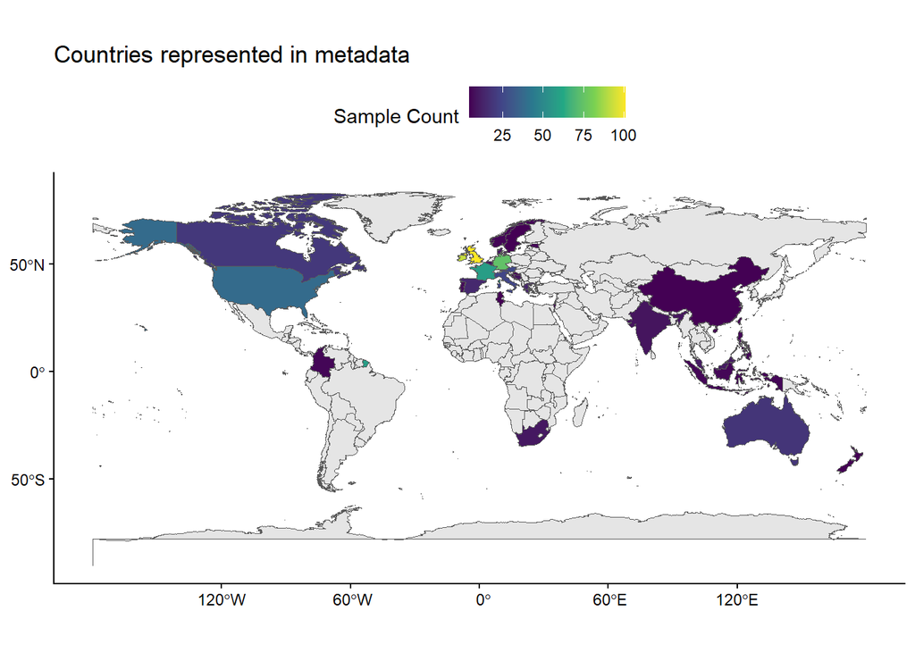

```r
world <- giscoR::gisco_get_countries(resolution = "10")

metadata <- read.table("../../data/metadata.txt",
                       header = TRUE,
                       sep = "\t",
                       check.names = FALSE,
                       comment.char = "",
                       quote = "",
                       na = ""
                       ) %>% as.data.frame()

metadata <- metadata %>%
  mutate(Origin = recode(Geographical_origin,
                         "USA"                    = "United States",
                         "UK"                     = "United Kingdom",
                         "USA"                    = "United States",
                         "South_Africa"           = "South Africa",
                         "New_Zealand"            = "New Zealand",
                         "Bosnia_and_Herzegovina" = "Bosnia and Herzegovina",
                         "HongKong_China"         = "Hong Kong"))

meta_counts <- metadata %>%
  group_by(Origin) %>%
  summarise(n = n(), .groups = "drop")

world_meta <- world %>%
  left_join(meta_counts, by = c("NAME_ENGL" = "Origin"))

map_plot <- ggplot(world_meta) +
  geom_sf(aes(fill = n)) +
  scale_fill_viridis_c(na.value = "grey90") +
  theme_classic() +
  theme(legend.position = "top") +
  labs(fill = "Sample Count",
       title = "Countries represented in metadata")

print(map_plot)
```

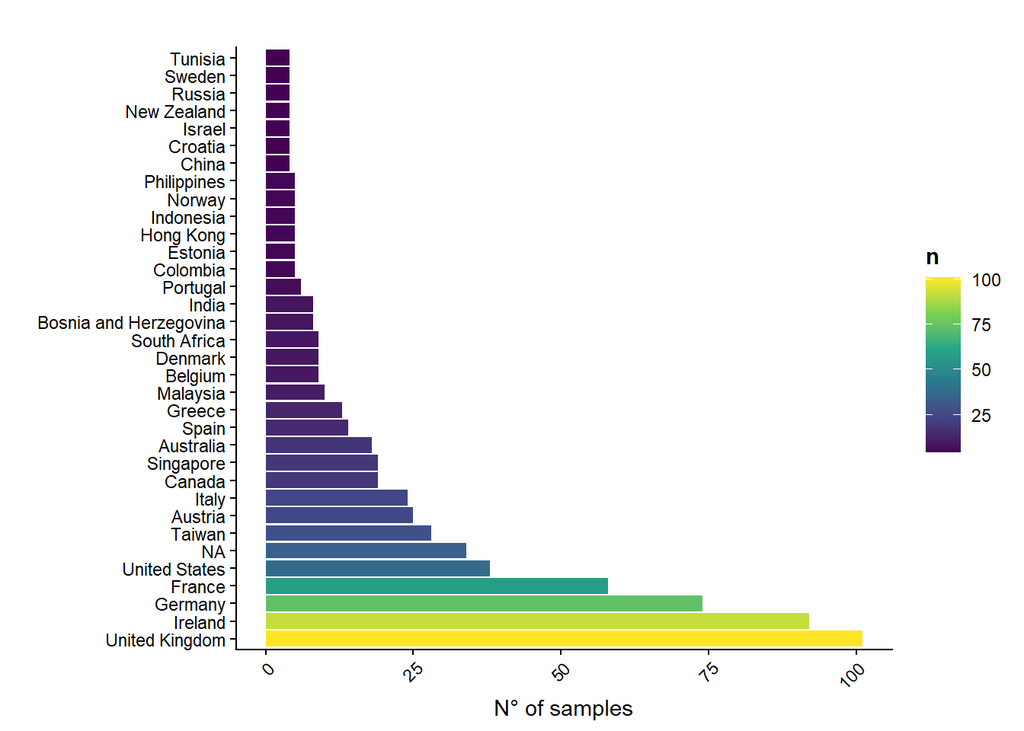

```r
bar_plot <- ggplot(meta_counts, aes(x = reorder(Origin, -n), y = n, fill = n)) +
  geom_col() +
  labs(x = "", y = "N° of samples", title = "") +
  scale_fill_viridis_c(na.value = "grey90") +
  coord_flip() +
  theme_classic() +
  theme(axis.text.x    = element_text(angle = 45, hjust = 1),
        legend.position = "right",
        legend.title    = element_text(face = "bold"))

print(bar_plot)
```

## Fig. 1B

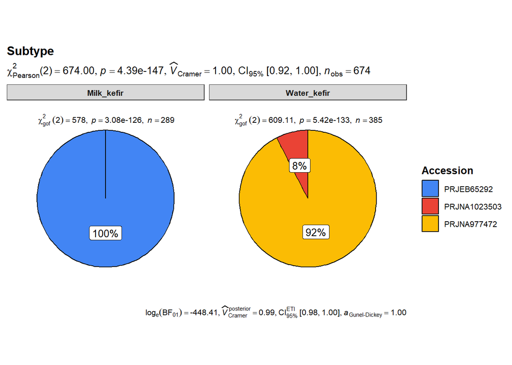

```r
metadata <- read.table("../../data/metadata.txt",
                       header = TRUE,
                       sep = "\t",
                       check.names = FALSE,
                       comment.char = "",
                       quote = "",
                       na = ""
                       ) %>% as.data.frame()

ggpiestats(
  data         = metadata,
  x            = Accession,
  y            = Subtype,
  title        = "Subtype",
  legend.title = "Accession"
)
```

## Fig. 1C

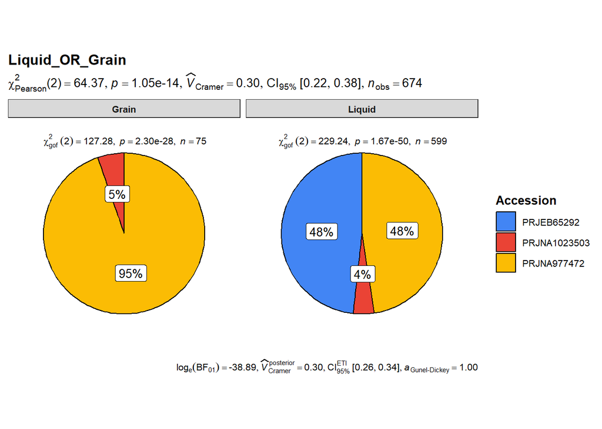

```r
metadata <- read.table("../../data/metadata.txt",
                       header = TRUE,
                       sep = "\t",
                       check.names = FALSE,
                       comment.char = "",
                       quote = "",
                       na = ""
                       ) %>% as.data.frame()

ggpiestats(
  data         = metadata,
  x            = Accession,
  y            = Liquid_OR_Grain,
  title        = "Liquid_OR_Grain",
  legend.title = "Accession"
)
```

## Fig. 2A

```r
alpha_Kefir <- read.table("../../data/alpha_diversity_Kefir.csv",
                          header = TRUE,
                          sep = ",",
                          check.names = FALSE,
                          comment.char = "",
                          quote = "",
                          na = ""
                          ) %>% as.data.frame()

unique(alpha_Kefir$Subtype)
```

```
[1] "Water_kefir" "Milk_kefir"
```

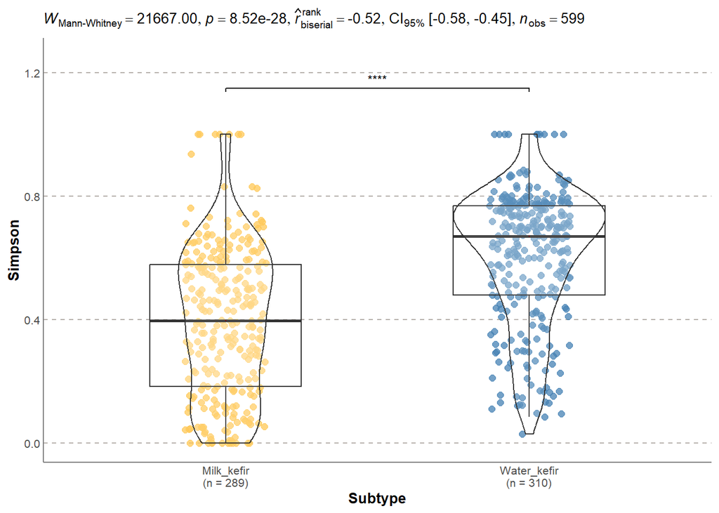

```r
Subtype <- c(
  "Water_kefir" = "steelblue",
  "Milk_kefir"  = "#FFC857"
)

# Simpson

simpson_subtype <- ggbetweenstats(
  data               = alpha_Kefir,
  x                  = Subtype,
  y                  = Simpson,
  type               = 'nonparametric',
  test               = 'wilcox.test',

  # Pairwise comparisons
  pairwise.comparisons = TRUE,
  pairwise.annotation  = 'p.value',
  pairwise.display     = 'all',
  p.adjust.method      = 'fdr',

  # Subtitle & descriptives
  results.subtitle     = TRUE,
  sample.size.label    = TRUE,
  mean.plotting        = TRUE,
  mean.ci              = TRUE,

  # Boxplot / violin / stats aesthetics
  centrality.point.args = list(size = 0, color = 'darkred'),
  centrality.label.args = list(label = NA,
                               size = 3,
                               nudge_x = 0.4,
                               segment.linetype   = 4,
                               min.segment.length = 0),
  point.args           = list(position = position_jitterdodge(dodge.width = 0.5),
                              alpha = 0.75, size = 2, stroke = 0.5, na.rm = TRUE),
  boxplot.args         = list(width = 0.5, alpha = 0.2, na.rm = TRUE),
  violin.args          = list(width = 0.5, alpha = 0.1, na.rm = TRUE),
  ggsignif.args        = list(textsize = 3, tip_length = 0.01, na.rm = TRUE),

  ggtheme              = theme_ggstatsplot(),
  package              = 'awtools',
  palette              = 'bpalette'
) +
  scale_color_manual(values = Subtype) +
  scale_fill_manual(values = Subtype) +
  theme(
    axis.ticks         = element_blank(),
    axis.line          = element_line(colour = 'grey50'),
    panel.grid         = element_line(color  = '#b4aea9'),
    panel.grid.minor   = element_blank(),
    panel.grid.major.x = element_blank(),
    panel.grid.major.y = element_line(linetype = 'dashed')
  )

# Extract statistics calculated by ggstatsplot
ggstats <- ggstatsplot::extract_stats(simpson_subtype)

# Extract ggstatsplot p-value
p_ggstats <- ggstats$subtitle_data$p.value

# Create significance label from ggstatsplot p-value
p_label <- dplyr::case_when(
  p_ggstats <= 0.0001 ~ "****",
  p_ggstats <= 0.001  ~ "***",
  p_ggstats <= 0.01   ~ "**",
  p_ggstats <= 0.05   ~ "*",
  TRUE                ~ "ns"
)

# Define y-position for bracket
y_max <- max(alpha_Kefir$Simpson, na.rm = TRUE)
y_min <- min(alpha_Kefir$Simpson, na.rm = TRUE)
y_range <- y_max - y_min

# Final plot with ggstatsplot p-value added as bracket annotation
simpson_subtype_sig <- simpson_subtype +
  ggsignif::geom_signif(
    comparisons = list(c("Water_kefir", "Milk_kefir")),
    annotations = p_label,
    manual = FALSE,
    textsize = 3,
    tip_length = 0.01,
    y_position = y_max + 0.10 * y_range
  ) +
  coord_cartesian(
    ylim = c(y_min, y_max + 0.25 * y_range),
    clip = "off"
  )

simpson_subtype_sig
```

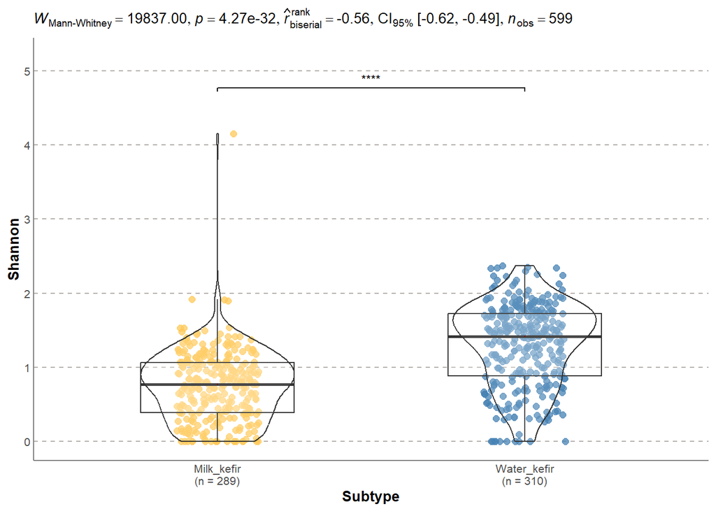

```r
# Shannon

shannon_subtype <- ggbetweenstats(
  data               = alpha_Kefir,
  x                  = Subtype,
  y                  = Shannon,
  type               = 'nonparametric',
  test               = 'wilcox.test',

  # Pairwise comparisons
  pairwise.comparisons = TRUE,
  pairwise.annotation  = 'p.value',
  pairwise.display     = 'all',
  p.adjust.method      = 'fdr',

  # Subtitle & descriptives
  results.subtitle     = TRUE,
  sample.size.label    = TRUE,
  mean.plotting        = TRUE,
  mean.ci              = TRUE,

  # Boxplot / violin / stats aesthetics
  centrality.point.args = list(size = 0, color = 'darkred'),
  centrality.label.args = list(label = NA,
                               size = 3,
                               nudge_x = 0.4,
                               segment.linetype   = 4,
                               min.segment.length = 0),
  point.args           = list(position = position_jitterdodge(dodge.width = 0.5),
                              alpha = 0.75, size = 2, stroke = 0.5, na.rm = TRUE),
  boxplot.args         = list(width = 0.5, alpha = 0.2, na.rm = TRUE),
  violin.args          = list(width = 0.5, alpha = 0.1, na.rm = TRUE),
  ggsignif.args        = list(textsize = 3, tip_length = 0.01, na.rm = TRUE),

  ggtheme              = theme_ggstatsplot(),
  package              = 'awtools',
  palette              = 'bpalette'
) +
  scale_color_manual(values = Subtype) +
  scale_fill_manual(values = Subtype) +
  theme(
    axis.ticks         = element_blank(),
    axis.line          = element_line(colour = 'grey50'),
    panel.grid         = element_line(color  = '#b4aea9'),
    panel.grid.minor   = element_blank(),
    panel.grid.major.x = element_blank(),
    panel.grid.major.y = element_line(linetype = 'dashed')
  )

# Extract statistics calculated by ggstatsplot
ggstats <- ggstatsplot::extract_stats(shannon_subtype)

# Extract ggstatsplot p-value
p_ggstats <- ggstats$subtitle_data$p.value

# Create significance label from ggstatsplot p-value
p_label <- dplyr::case_when(
  p_ggstats <= 0.0001 ~ "****",
  p_ggstats <= 0.001  ~ "***",
  p_ggstats <= 0.01   ~ "**",
  p_ggstats <= 0.05   ~ "*",
  TRUE                ~ "ns"
)

# Define y-position for bracket
y_max <- max(alpha_Kefir$Shannon, na.rm = TRUE)
y_min <- min(alpha_Kefir$Shannon, na.rm = TRUE)
y_range <- y_max - y_min

# Final plot with ggstatsplot p-value added as bracket annotation
shannon_subtype_sig <- shannon_subtype +
  ggsignif::geom_signif(
    comparisons = list(c("Water_kefir", "Milk_kefir")),
    annotations = p_label,
    manual = FALSE,
    textsize = 3,
    tip_length = 0.01,
    y_position = y_max + 0.10 * y_range
  ) +
  coord_cartesian(
    ylim = c(y_min, y_max + 0.25 * y_range),
    clip = "off"
  )

shannon_subtype_sig
```

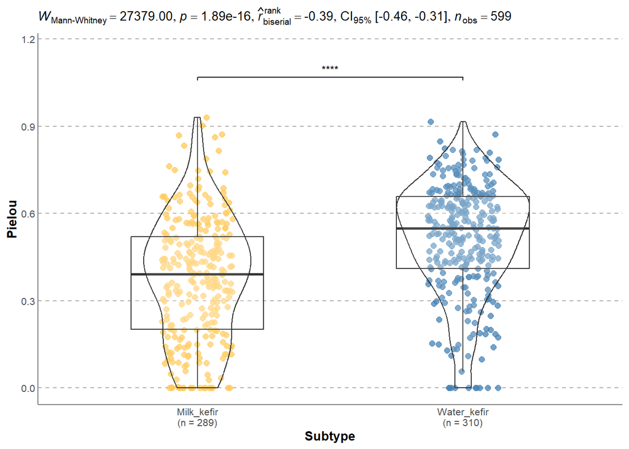

```r
# Pielou's Evenness

pielou_subtype <- ggbetweenstats(
  data               = alpha_Kefir,
  x                  = Subtype,
  y                  = Pielou,
  type               = 'nonparametric',
  test               = 'wilcox.test',

  # Pairwise comparisons
  pairwise.comparisons = TRUE,
  pairwise.annotation  = 'p.value',
  pairwise.display     = 'all',
  p.adjust.method      = 'fdr',

  # Subtitle & descriptives
  results.subtitle     = TRUE,
  sample.size.label    = TRUE,
  mean.plotting        = TRUE,
  mean.ci              = TRUE,

  # Boxplot / violin / stats aesthetics
  centrality.point.args = list(size = 0, color = 'darkred'),
  centrality.label.args = list(label = NA,
                               size = 3,
                               nudge_x = 0.4,
                               segment.linetype   = 4,
                               min.segment.length = 0),
  point.args           = list(position = position_jitterdodge(dodge.width = 0.5),
                              alpha = 0.75, size = 2, stroke = 0.5, na.rm = TRUE),
  boxplot.args         = list(width = 0.5, alpha = 0.2, na.rm = TRUE),
  violin.args          = list(width = 0.5, alpha = 0.1, na.rm = TRUE),
  ggsignif.args        = list(textsize = 3, tip_length = 0.01, na.rm = TRUE),

  ggtheme              = theme_ggstatsplot(),
  package              = 'awtools',
  palette              = 'bpalette'
) +
  scale_color_manual(values = Subtype) +
  scale_fill_manual(values = Subtype) +
  theme(
    axis.ticks         = element_blank(),
    axis.line          = element_line(colour = 'grey50'),
    panel.grid         = element_line(color  = '#b4aea9'),
    panel.grid.minor   = element_blank(),
    panel.grid.major.x = element_blank(),
    panel.grid.major.y = element_line(linetype = 'dashed')
  )

# Extract statistics calculated by ggstatsplot
ggstats <- ggstatsplot::extract_stats(pielou_subtype)

# Extract ggstatsplot p-value
p_ggstats <- ggstats$subtitle_data$p.value

# Create significance label from ggstatsplot p-value
p_label <- dplyr::case_when(
  p_ggstats <= 0.0001 ~ "****",
  p_ggstats <= 0.001  ~ "***",
  p_ggstats <= 0.01   ~ "**",
  p_ggstats <= 0.05   ~ "*",
  TRUE                ~ "ns"
)

# Define y-position for bracket
y_max <- max(alpha_Kefir$Pielou, na.rm = TRUE)
y_min <- min(alpha_Kefir$Pielou, na.rm = TRUE)
y_range <- y_max - y_min

# Final plot with ggstatsplot p-value added as bracket annotation
pielou_subtype_sig <- pielou_subtype +
  ggsignif::geom_signif(
    comparisons = list(c("Water_kefir", "Milk_kefir")),
    annotations = p_label,
    manual = FALSE,
    textsize = 3,
    tip_length = 0.01,
    y_position = y_max + 0.10 * y_range
  ) +
  coord_cartesian(
    ylim = c(y_min, y_max + 0.25 * y_range),
    clip = "off"
  )

pielou_subtype_sig
```

## Fig. 2B

```r
permdisp_df_bray <- read.table("../../data/permdisp_df_bray.csv",
                          header = TRUE,
                          sep = ",",
                          check.names = FALSE,
                          comment.char = "",
                          quote = "",
                          na = ""
                          ) %>% as.data.frame()

# Use the existing kefir palette for Subtype.
subtype_palette <- kefir_palettes[["Subtype"]]
permdisp_df_bray$color_id <- subtype_palette[permdisp_df_bray$Subtype]
permdisp_df_bray$color_id[is.na(permdisp_df_bray$color_id)] <- "grey50"
my_col_individual <- setNames(
  permdisp_df_bray$color_id,
  permdisp_df_bray$Subtype
)

# ---- 3. Pairwise Wilcoxon tests with FDR correction ----
permdisp_wilcox_df_bray <- permdisp_df_bray %>%
  filter(
    !is.na(Subtype),
    !is.na(DistanceToMedian)
  ) %>%
  group_by(Subtype) %>%
  filter(n() >= 2) %>%
  ungroup() %>%
  droplevels()

if (n_distinct(permdisp_wilcox_df_bray$Subtype) >= 2) {

  pairwise_results_bray <- permdisp_wilcox_df_bray %>%
    rstatix::wilcox_test(DistanceToMedian ~ Subtype) %>%
    rstatix::adjust_pvalue(method = "fdr") %>%
    rstatix::add_significance(
      p.col     = "p.adj",
      cutpoints = c(0, 0.0001, 0.001, 0.01, 0.05, 1),
      symbols   = c("****", "***", "**", "*", "ns")
    ) %>%
    filter(p.adj.signif != "ns")

} else {

  pairwise_results_bray <- tibble()
  cat(
    "Pairwise Wilcoxon tests skipped: fewer than 2 subtypes ",
    "with at least 2 observations.\n",
    sep = ""
  )
}

max_y_bray <- max(permdisp_df_bray$DistanceToMedian, na.rm = TRUE)

if (nrow(pairwise_results_bray) > 0) {

  pairwise_results_bray <- pairwise_results_bray %>%
    mutate(
      y.position = max_y_bray + row_number() * max_y_bray * 0.06
    )

  cat(
    "Significant pairwise Wilcoxon comparisons retained: ",
    nrow(pairwise_results_bray), "\n",
    sep = ""
  )

} else {

  cat("No significant pairwise Wilcoxon comparisons to annotate.\n")
}
```

```
Significant pairwise Wilcoxon comparisons retained: 1
```

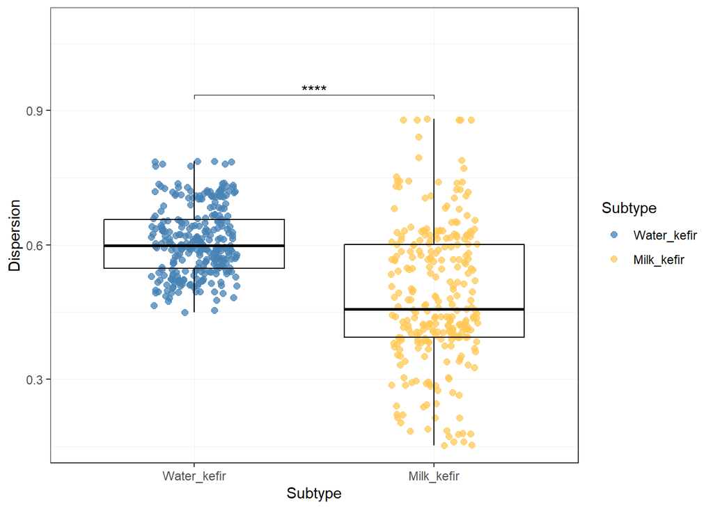

```r
# ---- 4. PERMDISP plot (corrected colour mapping) ----
# Make Subtype a factor with the order from the palette
permdisp_df_bray$Subtype <- factor(permdisp_df_bray$Subtype,
                                   levels = names(subtype_palette))

fig_permdisp_subtype_bray <- ggplot(permdisp_df_bray,
                                    aes(x = Subtype,
                                        y = DistanceToMedian,
                                        colour = Subtype)) +   # <-- map to Subtype, not color_id
  geom_jitter(width = 0.18,
              size  = 2,
              alpha = 0.75) +
  geom_boxplot(aes(group = Subtype),
               colour        = 'black',
               fill          = NA,
               outlier.shape = NA,
               linewidth     = 0.5) +
  scale_color_manual(values = subtype_palette,   # <-- direct use of the palette
                     name   = 'Subtype') +
  scale_y_continuous(expand = expansion(mult = c(0.05, 0.25))) +
  labs(
    title = NULL,
    x     = 'Subtype',
    y     = 'Dispersion'
  ) +
  theme_bw(base_size = 11) +
  theme(
    plot.title    = element_text(face = 'bold', size = 12, hjust = 0.5),
    plot.subtitle = element_text(size = 10, hjust = 0.5),
    axis.text.x   = element_text(angle = 0, hjust = 0.5),
    panel.grid    = element_line(colour = 'grey94', linewidth = 0.3),
    legend.position = 'right'
)

# Add significance brackets (unchanged)
if (nrow(pairwise_results_bray) > 0) {
  fig_permdisp_subtype_bray <- fig_permdisp_subtype_bray +
    stat_pvalue_manual(
      pairwise_results_bray,
      label      = 'p.adj.signif',
      xmin       = 'group1',
      xmax       = 'group2',
      y.position = 'y.position',
      tip.length = 0.01,
      size       = 4,
      colour     = 'black',
      hide.ns    = TRUE
    )
}

fig_permdisp_subtype_bray
```

## Fig. 2C

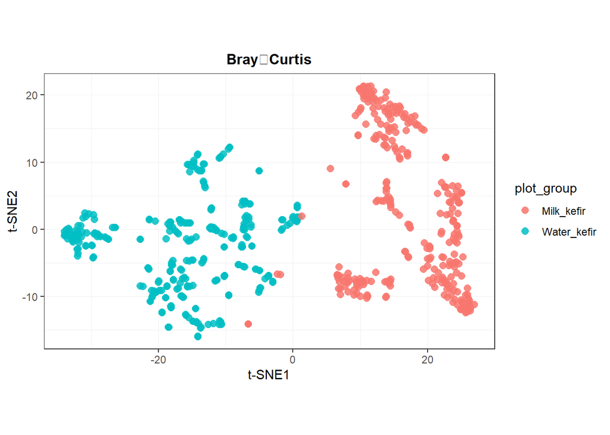

```r
tsne_df <- read.table("../../data/tsne_df.csv",
                          header = TRUE,
                          sep = ",",
                          check.names = FALSE,
                          comment.char = "",
                          quote = "",
                          na = ""
                          ) %>% as.data.frame()

wa_subset_tsne <- read.table("../../data/wa_subset_tsne.csv",
                          header = TRUE,
                          sep = ",",
                          check.names = FALSE,
                          comment.char = "",
                          quote = "",
                          na = ""
                          ) %>% as.data.frame()

fig_tsne <- ggplot(tsne_df,
                   aes(x = tSNE1, y = tSNE2, colour = plot_group)) +
  geom_point(size = 2.5, alpha = 0.85) +
  #scale_colour_manual(
    #values = plot_palette_tsne,
    #name   = plot_colour,
    #drop   = FALSE
  #) +
  coord_fixed() +
  labs(
    title    = paste0("Bray‑Curtis"),
    #subtitle = bquote(R^2 == .(r2_val) * ", " ~ italic(p) == .(pval_fmt)),
    x        = "t-SNE1",
    y        = "t-SNE2"
  ) +
  theme_bw(base_size = 11) +
  theme(
    plot.title    = element_text(face = "bold", size = 12, hjust = 0.5),
    plot.subtitle = element_text(hjust = 0.5, size = 10),
    panel.grid    = element_line(colour = "grey94", linewidth = 0.3),
    legend.position = "right"
  )

fig_tsne
```

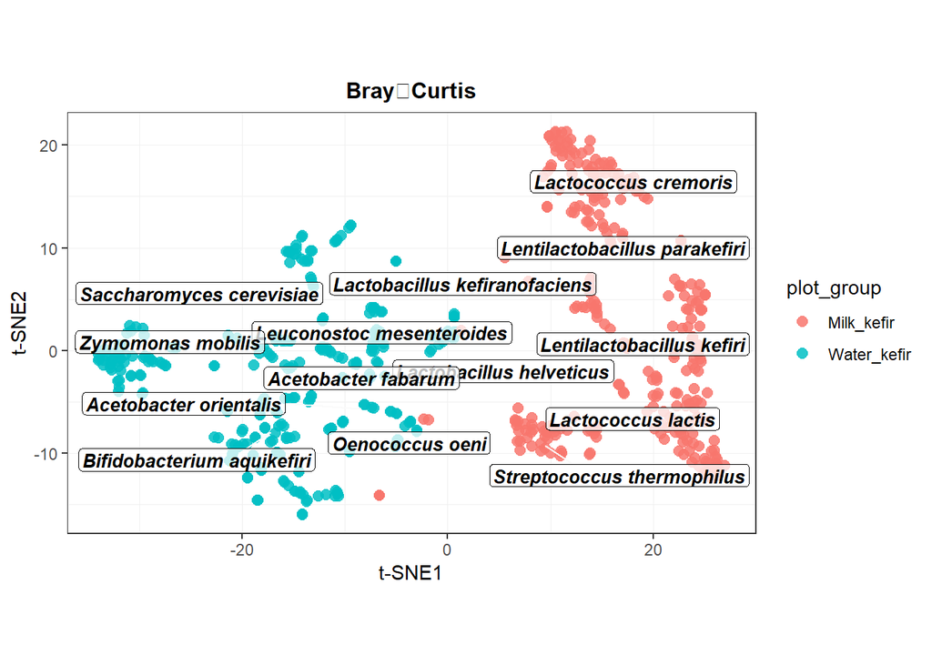

```r
fig_tsne_species <- fig_tsne +
  geom_label_repel(
    data = wa_subset_tsne,
    aes(x = tSNE1, y = tSNE2, label = species_label_plot),
    inherit.aes   = FALSE,
    colour        = "black",
    fill          = grDevices::adjustcolor("white", alpha.f = 0.75),
    fontface      = "bold.italic",
    size          = 3.5,
    label.size    = 0.25,
    label.r       = unit(0.15, "lines"),
    label.padding = unit(0.15, "lines"),
    box.padding   = 0.25,
    point.padding = 0.1,
    segment.color = "grey98"
  )

fig_tsne_species
```

## Fig. 3A

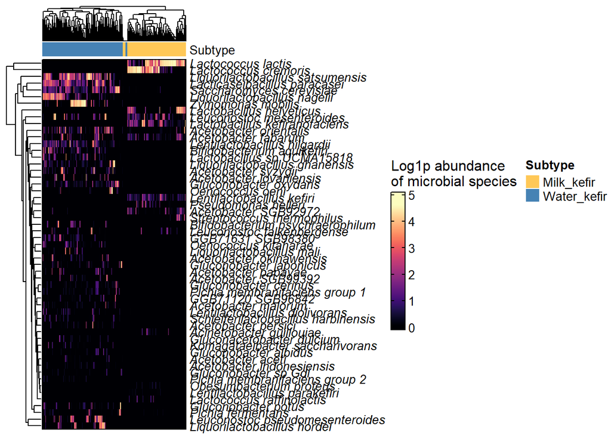

```r
kefir_palettes <- list(

  Subtype = c(
    "Water_kefir" = "steelblue",
    "Milk_kefir"  = "#FFC857"
  ),

  Liquid_OR_Grain = c(
    "Liquid" = "#E4572E",
    "Grain"  = "#A8C686"
  ),

  Sugar_source = c(
    "Brown"                   = "#D68C45",
    "Mix"                     = "#FFC9B9",
    "White"                   = "#FEFEE3",
    "Lactose"                 = "#DBD56E",
    "Lactose?_No_sugar_added" = "#120D31",
    "NA"                      = "lightgrey"
  ),

  Type_of_fermentation = c(
    "Anaerobe" = "#6A041D",
    "Aerobe"   = "#A7A5C6",
    "NA"       = "lightgrey"
  ),

  Timepoint = c(
    "0"  = "#FEF0D9",
    "2"  = "#FDBB84",
    "4"  = "#FC8D59",
    "8"  = "#E34A33",
    "16" = "#B30000",
    "24" = "#800000",
    "48" = "#4B0000",
    "NA" = "lightgrey"
  ),

  Fermentation_duration = c(
    "8"  = "#A1D99B",
    "24" = "#41AB5D",
    "48" = "#006D2C",
    "72" = "#003311",
    "NA" = "lightgrey"
  ),

  Fermentation_cycle = c(
    "1"  = "#66C2A5",
    "2"  = "#FC8D62",
    "NA" = "lightgrey"
  ),

  Temperature = c(
    "21" = "#5E4FA2",
    "24" = "#9E0142"
  ),

  Private_OR_Commercial = c(
    "Private"    = "#A3D9FF",
    "Commercial" = "#F2E94E",
    "NA"         = "lightgrey"
  ),

  Shipping_methods = c(
    "Fresh" = "#B5C99A",
    "Dried" = "#862B0D",
    "NA"    = "lightgrey"
  ),

  Geographical_origin = c(
    "Ireland"                = "#3B6B4F",
    "UK"                     = "#7A9D8C",
    "Germany"                = "#D9A066",
    "Spain"                  = "#C44536",
    "Italy"                  = "#6A994E",
    "Denmark"                = "#B5A1C4",
    "France"                 = "#5B7FA2",
    "Austria"                = "#A67C52",
    "USA"                    = "#9B5D73",
    "Indonesia"              = "#E6A176",
    "Canada"                 = "#8C5B4B",
    "Singapore"              = "#4D8C7A",
    "Australia"              = "#C27E3A",
    "Estonia"                = "#7A93A8",
    "Malaysia"               = "#D68C7C",
    "Norway"                 = "#5D7B93",
    "South_Africa"           = "#8B5A4A",
    "Belgium"                = "#A3A380",
    "Colombia"               = "#B87B6E",
    "Philippines"            = "#D4A373",
    "HongKong_China"         = "#6D8B8A",
    "China"                  = "#B54A4A",
    "Greece"                 = "#5F8B9E",
    "Israel"                 = "#C2A77D",
    "Tunisia"                = "#9B6E55",
    "Portugal"               = "#A66249",
    "Taiwan"                 = "#6A8D73",
    "New_Zealand"            = "#4F6D5C",
    "Bosnia_and_Herzegovina" = "#8B7D6B",
    "India"                  = "#CC8F5A",
    "Russia"                 = "#7B6F8A",
    "Croatia"                = "#5A8F8F",
    "Sweden"                 = "#8B9A6B",
    "NA"                     = "lightgrey"
  )
)

s_metaKefir_log1p <- read.table("../../data/s_metaKefir_log1p.tsv",
                      header       = TRUE,
                      row.names    = 1,
                      sep          = "\t",
                      check.names  = FALSE,
                      dec          = ".",
                      comment.char = "",
                      quote        = ""
                      ) %>% as.data.frame()

species_cols <- grep("^s__", colnames(s_metaKefir_log1p), value = TRUE)

if (length(species_cols) == 0) {
  stop("No species columns found. Expected columns starting with 's__'.")
}

s_metaKefir_heatmap <- t(as.matrix(s_metaKefir_log1p[, species_cols, drop = FALSE]))

rownames(s_metaKefir_heatmap) <- rownames(s_metaKefir_heatmap) |>
  sub("^s__", "", x = _) |>
  gsub("_", " ", x = _)

viridis_palette <- magma(100)          # Magma

clean_metadata_level <- function(x) {
  x <- as.character(x)
  x[is.na(x) | x == "" | x == "NaN" | x == "nan" | x == "<NA>"] <- "NA"
  x
}

s_metaKefir_log1p$Subtype_clean            <- clean_metadata_level(s_metaKefir_log1p$Subtype)
s_metaKefir_log1p$Liquid_OR_Grain_clean    <- clean_metadata_level(s_metaKefir_log1p$Liquid_OR_Grain)
s_metaKefir_log1p$Sugar_source_clean       <- clean_metadata_level(s_metaKefir_log1p$Sugar_source)
s_metaKefir_log1p$Type_of_fermentation_clean <- clean_metadata_level(s_metaKefir_log1p$Type_of_fermentation)
s_metaKefir_log1p$Timepoint_clean          <- clean_metadata_level(s_metaKefir_log1p$Timepoint)
s_metaKefir_log1p$Fermentation_duration_clean <- clean_metadata_level(s_metaKefir_log1p$Fermentation_duration)
s_metaKefir_log1p$Fermentation_cycle_clean <- clean_metadata_level(s_metaKefir_log1p$Fermentation_cycle)
s_metaKefir_log1p$Temperature_clean        <- clean_metadata_level(s_metaKefir_log1p$Temperature)
s_metaKefir_log1p$Private_OR_Commercial_clean <- clean_metadata_level(s_metaKefir_log1p$Private_OR_Commercial)
s_metaKefir_log1p$Shipping_methods_clean   <- clean_metadata_level(s_metaKefir_log1p$Shipping_methods)
s_metaKefir_log1p$Geographical_origin_clean <- clean_metadata_level(s_metaKefir_log1p$Geographical_origin)

ha <- HeatmapAnnotation(
  Subtype            = s_metaKefir_log1p$Subtype_clean,
  #Liquid_OR_Grain    = s_metaKefir_log1p$Liquid_OR_Grain_clean,
  #Sugar_source       = s_metaKefir_log1p$Sugar_source_clean,
  #Type_of_fermentation = s_metaKefir_log1p$Type_of_fermentation_clean,
  #Timepoint          = s_metaKefir_log1p$Timepoint_clean,
  #Fermentation_duration = s_metaKefir_log1p$Fermentation_duration_clean,
  #Fermentation_cycle = s_metaKefir_log1p$Fermentation_cycle_clean,
  #Temperature        = s_metaKefir_log1p$Temperature_clean,
  #Private_OR_Commercial = s_metaKefir_log1p$Private_OR_Commercial_clean,
  #Shipping_methods   = s_metaKefir_log1p$Shipping_methods_clean,
  #Geographical_origin = s_metaKefir_log1p$Geographical_origin_clean,

  # Apply the colour scheme from your kefir_palettes
  col = kefir_palettes,

  annotation_name_gp = gpar(fontsize = 10),
  simple_anno_size = unit(4, "mm")
)

all_heatmap <- Heatmap(
  matrix = s_metaKefir_heatmap,
  name = "Log1p abundance\nof microbial species",
  col = viridis_palette,
  na_col = "grey90",

  top_annotation = ha,

  cluster_rows = TRUE,
  cluster_columns = TRUE,
  clustering_distance_rows = "euclidean",
  clustering_method_rows = "complete",
  show_row_dend = TRUE,
  row_dend_reorder = TRUE,

  show_column_names = FALSE,
  border = TRUE,
  row_gap = unit(2, "mm"),
  column_gap = unit(1, "mm"),

  row_names_gp = gpar(fontsize = 10, fontface = "italic"),
  column_names_gp = gpar(fontsize = 10),
  row_title_gp = gpar(fontsize = 12),

  heatmap_legend_param = list(
    title_gp = gpar(fontsize = 12),
    labels_gp = gpar(fontsize = 10),
    legend_height = unit(4, "cm"),
    direction = "vertical",
    border = "black"
  )
)

all_heatmap
```

```r
species_cols <- grep("^s__", colnames(s_metaKefir_log1p), value = TRUE)

if (length(species_cols) == 0) {
  stop("No species columns found. Expected columns starting with 's__'.")
}

s_metaKefir_heatmap <- t(as.matrix(s_metaKefir_log1p[, species_cols, drop = FALSE]))

rownames(s_metaKefir_heatmap) <- rownames(s_metaKefir_heatmap) |>
  sub("^s__", "", x = _) |>
  gsub("_", " ", x = _)

clean_metadata_level <- function(x) {
  x <- as.character(x)
  x[is.na(x) | x == "" | x == "NaN" | x == "nan" | x == "<NA>"] <- "NA"
  x
}

split_variable <- clean_metadata_level(s_metaKefir_log1p$Subtype)

cat("Split levels: ", paste(unique(split_variable), collapse = ", "), "\n")
```

```
Split levels:  Water_kefir, Milk_kefir
```

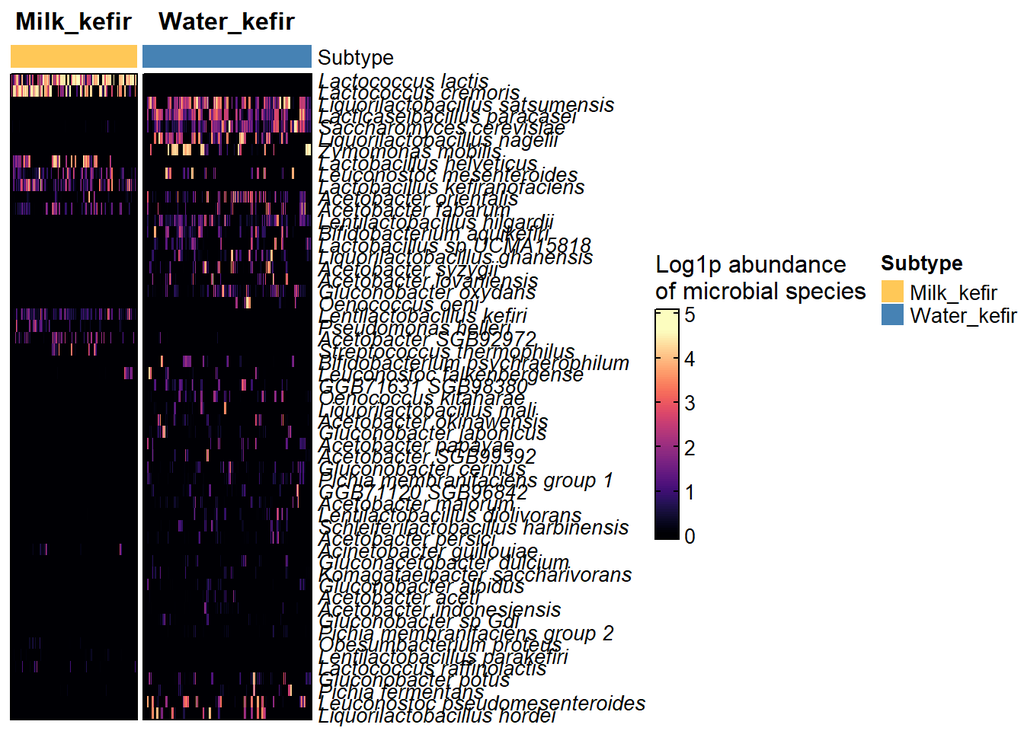

```r
viridis_palette <- magma(100)
all_heatmap_matrix_split <- Heatmap(
  matrix = s_metaKefir_heatmap,
  name = "Log1p abundance\nof microbial species",
  col = viridis_palette,
  na_col = "grey90",

  top_annotation = ha,

  column_split = split_variable,
  column_title_gp = gpar(fontsize = 12, fontface = "bold"),

  cluster_rows = TRUE,
  cluster_columns = FALSE,
  clustering_distance_rows = "euclidean",
  clustering_method_rows = "complete",
  show_row_dend = FALSE,
  row_dend_reorder = TRUE,
  cluster_column_slices = FALSE,

  show_column_names = FALSE,
  border = TRUE,
  row_gap = unit(2, "mm"),
  column_gap = unit(1, "mm"),

  row_names_gp = gpar(fontsize = 10, fontface = "italic"),
  column_names_gp = gpar(fontsize = 10),
  row_title_gp = gpar(fontsize = 12),

  heatmap_legend_param = list(
    title_gp = gpar(fontsize = 12),
    labels_gp = gpar(fontsize = 10),
    legend_height = unit(4, "cm"),
    direction = "vertical",
    border = "black"
  )
)

all_heatmap_matrix_split
```

## Fig. 3B

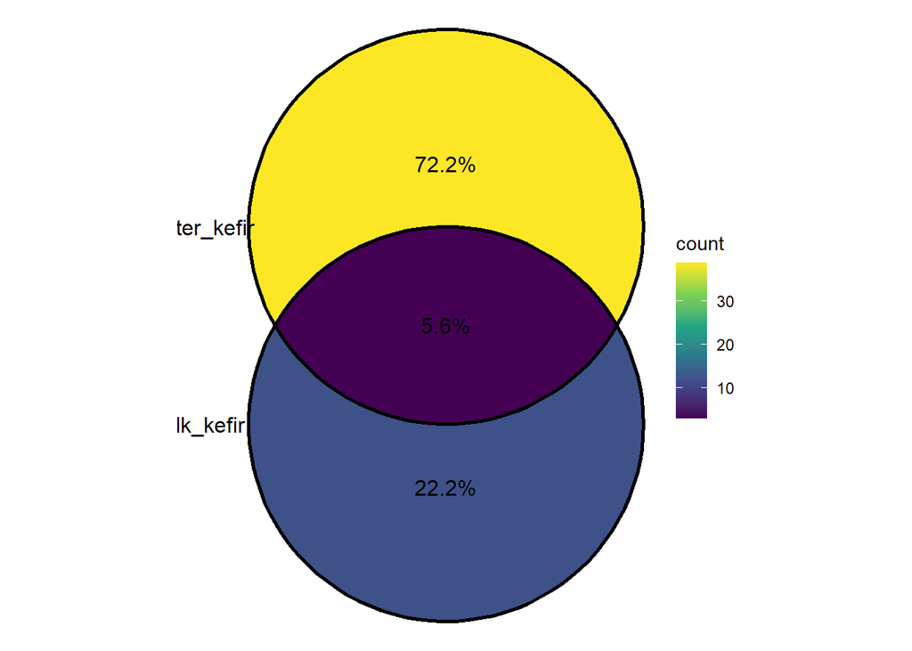

```r
core_sets_df <- read.csv(
  "../../data/core_sets_df.csv",
  row.names = 1,
  check.names = FALSE,
  colClasses = "character",
  na.strings = c("NA", "")
)

core_sets <- lapply(core_sets_df, function(taxa) {
  taxa[!is.na(taxa)]
})

venn_plot <- ggVennDiagram(
  core_sets,
  label = "percent",
  label_percent_digit = 1,
  label_alpha = 0
) +
  scale_fill_viridis_c(option = "D", direction = 1) +
  theme_void()

print(venn_plot)
```

## Fig. 3C

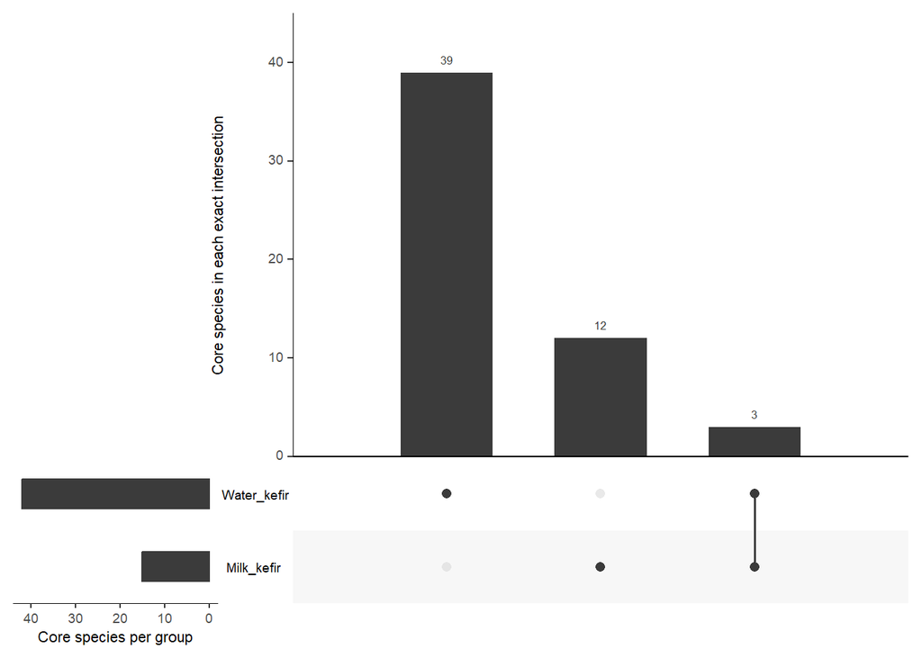

```r
incidence <- read.table("../../data/incidence.csv",
                        header       = TRUE,
                        row.names    = 1,
                        sep          = ",",
                        check.names  = FALSE,
                        dec          = ".",
                        comment.char = "",
                        quote        = ""
                        ) %>% as.data.frame()

upset(
  incidence,
  sets = colnames(incidence),
  nsets = ncol(incidence),
  keep.order = TRUE,
  order.by = "freq",
  mainbar.y.label = "Core species in each exact intersection",
  sets.x.label = "Core species per group"
)
```

## Fig. 5A

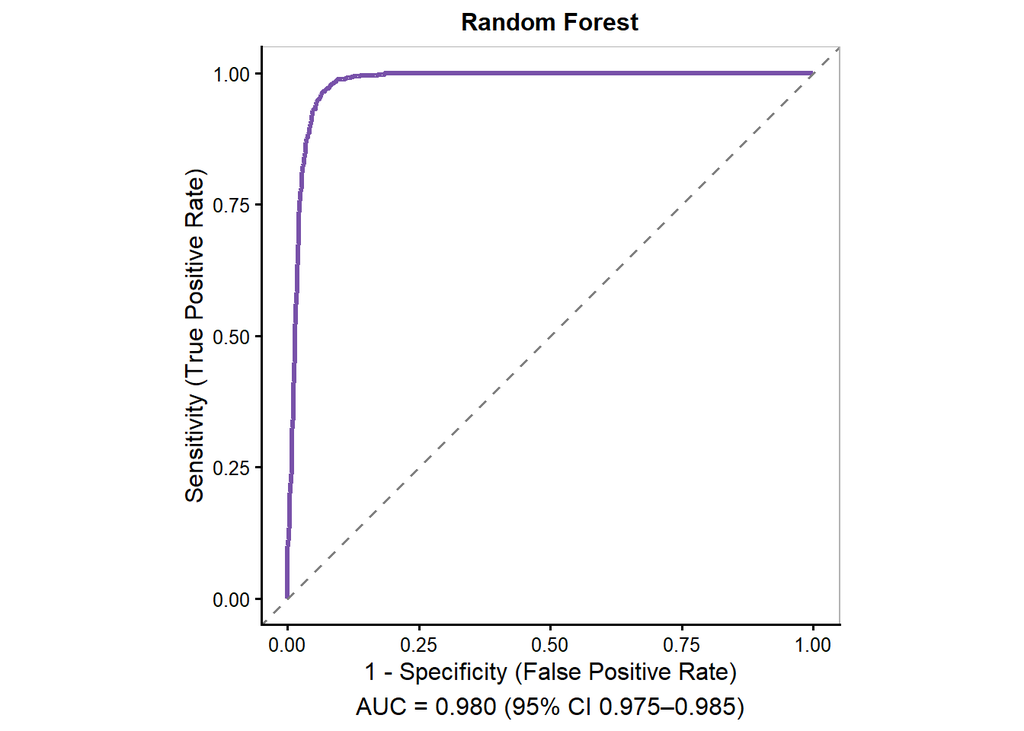

```r
roc_df <- read.table("../../data/roc_df.csv",
                     header       = TRUE,
                     row.names    = 1,
                     sep          = ",",
                     check.names  = FALSE,
                     dec          = ".",
                     comment.char = "",
                     quote        = ""
                     ) %>% as.data.frame()

roc_auc_df <- read.table("../../data/roc_auc_df.csv",
                     header       = TRUE,
                     row.names    = 1,
                     sep          = ",",
                     check.names  = FALSE,
                     dec          = ".",
                     comment.char = "",
                     quote        = ""
                     ) %>% as.data.frame()

auc_label <- sprintf(
  "AUC = %.3f (95%% CI %.3f–%.3f)",
  roc_auc_df$auc,
  roc_auc_df$ci_lower,
  roc_auc_df$ci_upper
)

p_roc <- ggplot(roc_df, aes(x = fpr, y = tpr)) +
  geom_step(color = "#7851A9", linewidth = 1.2) +
  geom_abline(linetype = "dashed", color = "grey50") +
  coord_equal() +
  labs(
    title = "Random Forest",
    x = "1 - Specificity (False Positive Rate)",
    y = "Sensitivity (True Positive Rate)",
    caption = auc_label
  ) +
  theme_classic(base_size = 12) +
  theme(
    plot.title = element_text(hjust = 0.5, face = "bold", size = 12),
    plot.caption = element_text(hjust = 0.5, size = 12),
    panel.grid.minor = element_blank(),
    panel.border = element_rect(fill = NA, colour = "grey70", linewidth = 0.5)
  )

print(p_roc)
```

## Fig. 5B

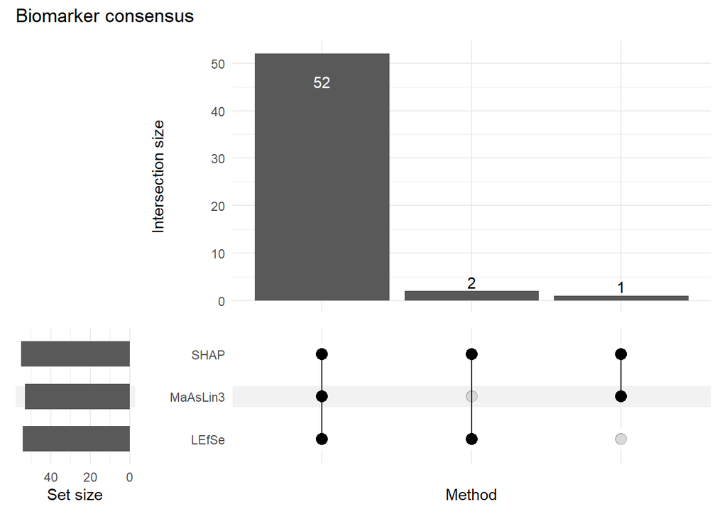

```r
consensus_df <- read.table("../../data/consensus_df.tsv",
                     header       = TRUE,
                     #row.names    = 1,
                     sep          = "\t",
                     check.names  = FALSE,
                     dec          = ".",
                     comment.char = "",
                     quote        = ""
                     ) %>% as.data.frame()

if (nrow(consensus_df) > 0L) {

  p_upset <- ComplexUpset::upset(
    consensus_df,
    intersect   = c("LEfSe", "MaAsLin3", "SHAP"),
    name        = "Method",
    min_size    = 1,
    sort_sets   = FALSE,
    width_ratio = 0.2,
    base_annotations = list(
      "Intersection size" = ComplexUpset::intersection_size()
    )
  ) +
    patchwork::plot_annotation(
      title   = "Biomarker consensus",
      caption = get0("selection_caption", ifnotfound = NULL)
    )

  print(p_upset)

} else {
  message("No selected biomarkers to plot.")
}
```

## Fig. 5C

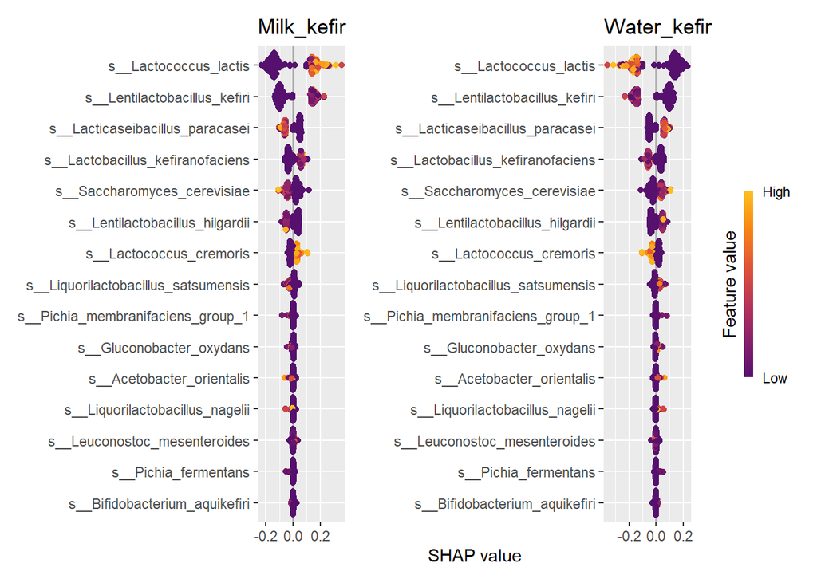

```r
ks_Subtype_df <- readr::read_csv(
  "../../data/ks_Subtype_df.csv",
  col_types = readr::cols(
    Run           = readr::col_character(),
    Subtype       = readr::col_character(),
    feature       = readr::col_character(),
    feature_value = readr::col_double(),
    shap_value    = readr::col_double(),
    baseline      = readr::col_double()
  )
)

# 18d) Rebuild the SHAP and feature-value matrices for each subtype
subtypes <- unique(ks_Subtype_df$Subtype)

# Rebuild one shapviz object per subtype
sv_by_subtype <- list()

for (subtype in unique(ks_Subtype_df$Subtype)) {
  d <- dplyr::filter(ks_Subtype_df, Subtype == subtype)

  S <- d |>
    tidyr::pivot_wider(id_cols = Run, names_from = feature, values_from = shap_value) |>
    tibble::column_to_rownames("Run") |>
    as.matrix()

  X <- d |>
    tidyr::pivot_wider(id_cols = Run, names_from = feature, values_from = feature_value) |>
    tibble::column_to_rownames("Run")

  sv_by_subtype[[subtype]] <- shapviz::shapviz(S, X = X, baseline = d$baseline[1])
}

sv_Subtype <- shapviz::mshapviz(sv_by_subtype)

p_bee <- shapviz::sv_importance(sv_Subtype, kind = "beeswarm")
print(p_bee)
```

## Fig. 6A

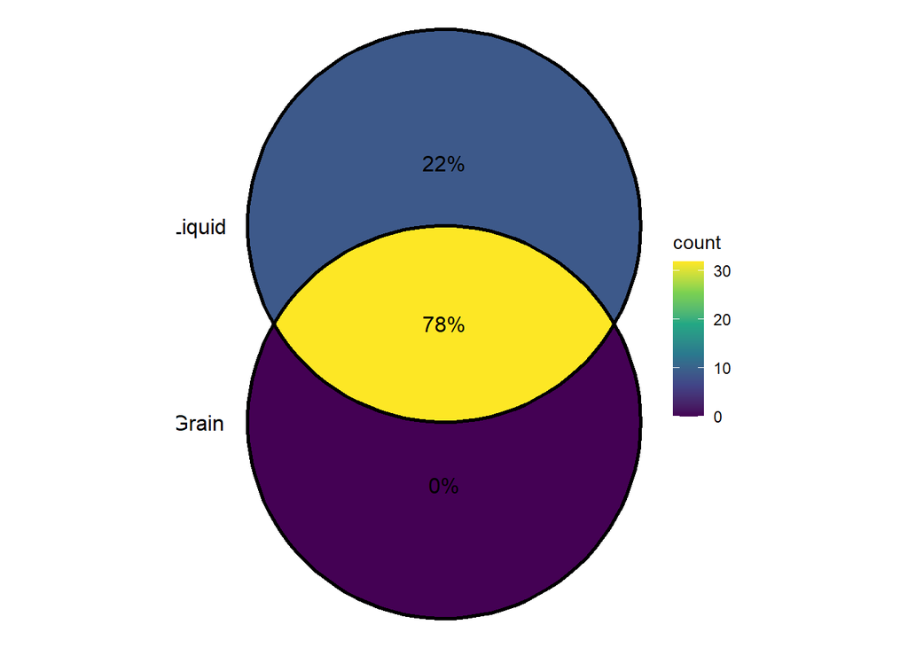

```r
core_sets_df_GRAINvsLIQUID <- read.csv(
  "../../data/core_sets_df_GRAINvsLIQUID.csv",
  row.names = 1,
  check.names = FALSE,
  colClasses = "character",
  na.strings = c("NA", "")
)

core_sets_GRAINvsLIQUID <- lapply(core_sets_df_GRAINvsLIQUID, function(taxa) {
  taxa[!is.na(taxa)]
})

venn_plot_GRAINvsLIQUID <- ggVennDiagram(
  core_sets_GRAINvsLIQUID,
  label = "percent",
  label_percent_digit = 1,
  label_alpha = 0
) +
  scale_fill_viridis_c(option = "D", direction = 1) +
  theme_void()

print(venn_plot_GRAINvsLIQUID)
```

## Fig. 6B

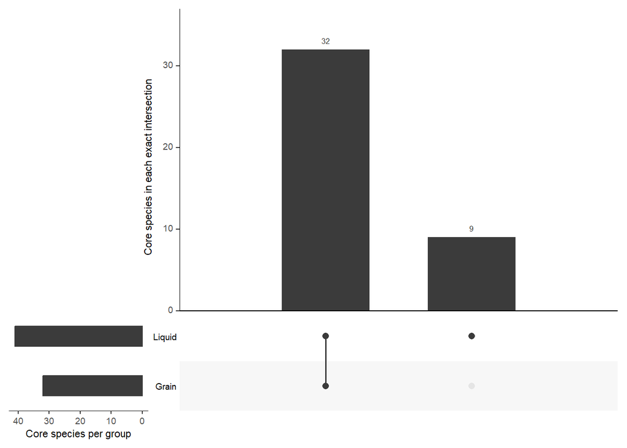

```r
incidence_GRAINvsLIQUID <- read.table("../../data/incidence_GRAINvsLIQUID.csv",
                        header       = TRUE,
                        row.names    = 1,
                        sep          = ",",
                        check.names  = FALSE,
                        dec          = ".",
                        comment.char = "",
                        quote        = ""
                        ) %>% as.data.frame()

upset(
  incidence_GRAINvsLIQUID,
  sets = colnames(incidence_GRAINvsLIQUID),
  nsets = ncol(incidence_GRAINvsLIQUID),
  keep.order = TRUE,
  order.by = "freq",
  mainbar.y.label = "Core species in each exact intersection",
  sets.x.label = "Core species per group"
)
```

## Fig. 7A

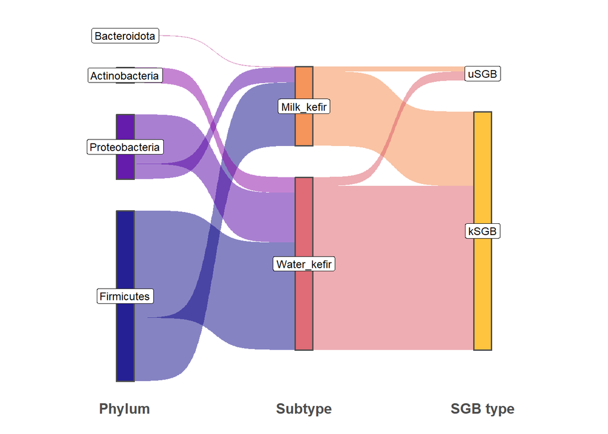

```r
sankey_df <- readr::read_csv(
  "../../data/sankey_df.csv",
  col_types = cols(.default = col_character()),
  na = c("", "NA")
)

stage_levels <- c("phylum", "Subtype", "SGB_type")

# Preserve first appearance within each stage, with kSGB and uSGB last.
sgb_nodes <- unique(sankey_df$node[sankey_df$x == "SGB_type"])

node_levels <- c(
  unique(sankey_df$node[sankey_df$x == "phylum"]),
  unique(sankey_df$node[sankey_df$x == "Subtype"]),
  setdiff(sgb_nodes, c("kSGB", "uSGB")),
  "kSGB", "uSGB"
)

sankey_df <- sankey_df %>%
  mutate(
    x      = factor(x, levels = stage_levels),
    next_x = factor(next_x, levels = stage_levels),
    node   = factor(node, levels = node_levels),

    # Restore the next_node ordering used in the original script.
    next_node = if_else(next_node == "uSGB", "zzz_uSGB", next_node),
    next_node = forcats::fct_recode(factor(next_node), "uSGB" = "zzz_uSGB")
  )

ggplot(sankey_df, aes(
  x = x, next_x = next_x,
  node = node, next_node = next_node,
  fill = node, label = node
)) +
  geom_sankey(flow.alpha = 0.5, node.color = "gray30", show.legend = FALSE) +
  geom_sankey_label(size = 3.2, color = "black", fill = "white", hjust = 0.5) +
  theme_sankey(base_size = 15) +
  theme(
    axis.title.x = element_blank(),
    axis.text.x  = element_text(face = "bold", size = 12),
    plot.title   = element_text(hjust = 0.5, face = "bold"),
    plot.margin  = margin(15, 15, 15, 15, "pt")
  ) +
  scale_x_discrete(labels = c("phylum" = "Phylum",
                              "Subtype" = "Subtype",
                              "SGB_type" = "SGB type")) +
  labs(title = NULL) +
  scale_fill_viridis_d(option = "plasma", alpha = 0.9)
```

## Fig. 7C

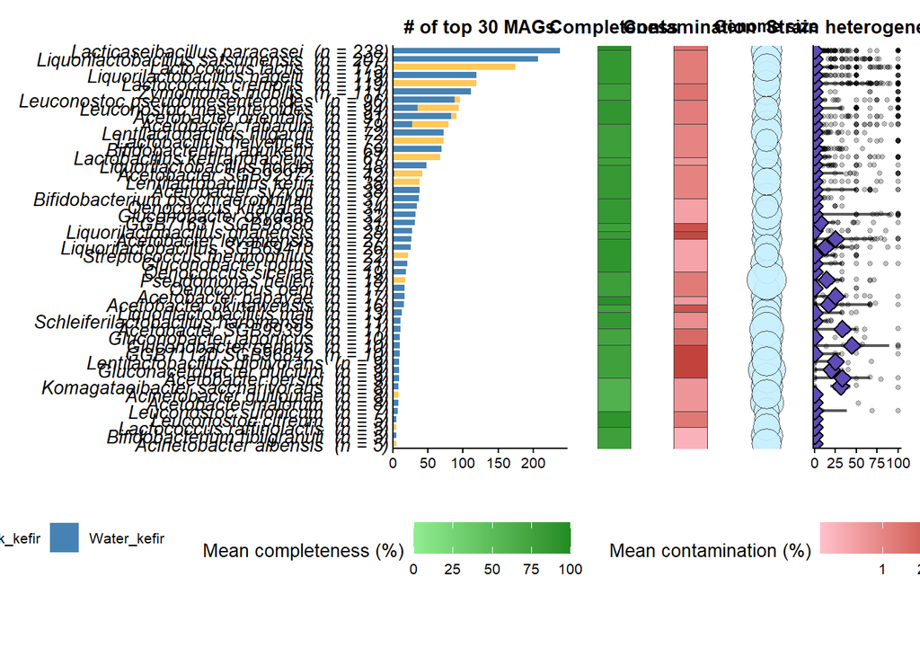

```r
mags_overview <- read.table(
  "../../data/mags_overview.tsv",
  header       = TRUE,
  sep          = "\t",
  check.names  = FALSE,
  dec          = ".",
  comment.char = "",
  quote        = "\"",
  na.strings   = "NA"
)

# Restore the original species order, including ties in MAG count.
species_levels <- mags_overview %>%
  dplyr::distinct(species_order, Species_label) %>%
  dplyr::arrange(species_order) %>%
  dplyr::pull(Species_label)

mags_overview <- mags_overview %>%
  dplyr::mutate(
    Species_plot = factor(Species_label, levels = species_levels)
  )

# Sections 9–11: one row per species for the squares and bubbles
species_plot <- mags_overview %>%
  dplyr::distinct(
    Species, Species_label, Species_plot, n_MAGs,
    mean_completeness, mean_contamination, mean_genome_Mbp,
    median_SH, Q1_SH, Q3_SH
  )

# Section 12: one row per MAG for the individual points, median, and IQR
mag_plot <- mags_overview %>%
  dplyr::select(Name, Species, Species_plot, Strain_heterogeneity)

# Section 8: one row per species and subtype for the stacked bars
subtype_plot_df <- mags_overview %>%
  dplyr::count(Species, Species_label, Species_plot, Subtype, name = "count")

Subtype <- c(
  "Water_kefir" = "steelblue",
  "Milk_kefir"  = "#FFC857"
)

p_subtype <- ggplot(
  subtype_plot_df,
  aes(x = count, y = Species_plot, fill = Subtype)
) +
  geom_col(width = 0.72) +
  scale_fill_manual(
    values = Subtype,
    na.value = "grey50",
    name = "Kefir subtype"
  ) +
  scale_x_continuous(
    breaks = breaks_pretty(n = 4),
    expand = expansion(mult = c(0, 0.04))
  ) +
  labs(
    x = "",
    y = NULL,
    title = "# of top 30 MAGs"
  ) +
  theme_classic(base_size = 10) +
  theme(
    text = element_text(size = 10),
    axis.text.y = element_text(
      face = "italic",
      size = 10,
      colour = "black"
    ),
    axis.ticks.y = element_blank(),
    plot.title = element_text(
      face = "bold",
      hjust = 0.5,
      size = 10
    )
  )


# ------------------------------------------------
# 9. Mean completeness
# ------------------------------------------------
# One square per species; fill represents the species mean.

p_completeness <- ggplot(
  species_plot,
  aes(x = 1, y = Species_plot)
) +
  geom_point(
    aes(fill = mean_completeness),
    shape = 22,
    size = 9.5,
    colour = "grey25",
    stroke = 0.25
  ) +
  scale_fill_gradient(
    low = "lightgreen",
    high = "forestgreen",
    limits = c(0, 100),
    name = "Mean completeness (%)"
  ) +
  scale_x_continuous(breaks = NULL) +
  labs(x = NULL, y = NULL, title = "Completeness") +
  theme_classic(base_size = 10) +
  theme(
    text = element_text(size = 10),
    axis.text.y = element_blank(),
    axis.ticks.y = element_blank(),
    axis.line = element_blank(),
    plot.title = element_text(
      face = "bold",
      hjust = 0.5,
      size = 10
    )
  )


# ------------------------------------------------
# 10. Mean contamination
# ------------------------------------------------
# sqrt affects only the colour scale, not the underlying values.

p_contamination <- ggplot(
  species_plot,
  aes(x = 1, y = Species_plot)
) +
  geom_point(
    aes(fill = mean_contamination),
    shape = 22,
    size = 9.5,
    colour = "grey25",
    stroke = 0.25
  ) +
  scale_fill_gradient(
    low = "pink",
    high = "firebrick",
    trans = "sqrt",
    name = "Mean contamination (%)"
  ) +
  scale_x_continuous(breaks = NULL) +
  labs(x = NULL, y = NULL, title = "Contamination") +
  theme_classic(base_size = 10) +
  theme(
    text = element_text(size = 10),
    axis.text.y = element_blank(),
    axis.ticks.y = element_blank(),
    axis.line = element_blank(),
    plot.title = element_text(
      face = "bold",
      hjust = 0.5,
      size = 10
    )
  )


# ------------------------------------------------
# 11. Mean genome size
# ------------------------------------------------
# Bubble AREA is proportional to mean genome size.

p_genome_size <- ggplot(
  species_plot,
  aes(x = 1, y = Species_plot)
) +
  geom_point(
    aes(size = mean_genome_Mbp),
    shape = 21,
    fill = "#C9F0FF",
    colour = "grey25",
    stroke = 0.4,
    alpha = 0.9
  ) +
  scale_size_area(
    max_size = 10,
    name = "Mean genome size (Mbp)"
  ) +
  scale_x_continuous(breaks = NULL) +
  labs(x = NULL, y = NULL, title = "Genome size") +
  theme_classic(base_size = 10) +
  theme(
    text = element_text(size = 10),
    axis.text.y = element_blank(),
    axis.ticks.y = element_blank(),
    axis.line = element_blank(),
    plot.title = element_text(
      face = "bold",
      hjust = 0.5,
      size = 9.5
    )
  )


# ------------------------------------------------
# 12. Strain heterogeneity
# ------------------------------------------------
# Small points = individual MAGs
# Horizontal segment = species IQR
# Diamond = species median

sh_summary <- mag_plot %>%
  group_by(Species_plot) %>%
  summarise(
    median_SH = median(Strain_heterogeneity),
    Q1_SH = quantile(Strain_heterogeneity, 0.25),
    Q3_SH = quantile(Strain_heterogeneity, 0.75),
    .groups = "drop"
  )

p_strain <- ggplot() +
  geom_segment(
    data = sh_summary,
    aes(
      x = Q1_SH,
      xend = Q3_SH,
      y = Species_plot,
      yend = Species_plot
    ),
    linewidth = 0.75,
    colour = "grey35"
  ) +
  ggbeeswarm::geom_quasirandom(
    data = mag_plot,
    aes(
      x = Strain_heterogeneity,
      y = Species_plot
    ),
    groupOnX = FALSE,
    width = 0.25,
    size = 1.15,
    alpha = 0.25
  ) +
  geom_point(
    data = sh_summary,
    aes(
      x = median_SH,
      y = Species_plot
    ),
    shape = 23,
    size = 3,
    fill = "#5F4BB6",
    colour = "black",
    stroke = 0.75
  ) +
  scale_x_continuous(
    limits = c(0, 100),
    breaks = seq(0, 100, 25),
    expand = expansion(mult = c(0.01, 0.03))
  ) +
  labs(
    x = "",
    y = NULL,
    title = "Strain heterogeneity"
  ) +
  theme_classic(base_size = 10) +
  theme(
    text = element_text(size = 10),
    axis.text.y = element_blank(),
    axis.ticks.y = element_blank(),
    plot.title = element_text(
      face = "bold",
      hjust = 0.5,
      size = 10
    )
  )


# ------------------------------------------------
# 13. Assemble the five aligned panels
# ------------------------------------------------

p_final <- (
  p_subtype |
  p_completeness |
  p_contamination |
  p_genome_size |
  p_strain
) +
  plot_layout(
    widths = c(3, 1, 1, 1, 1.5),
    guides = "collect"
  ) &
  theme(
    text = element_text(size = 10),
    legend.position = "bottom"
  )

p_final
```

## Fig. 8A

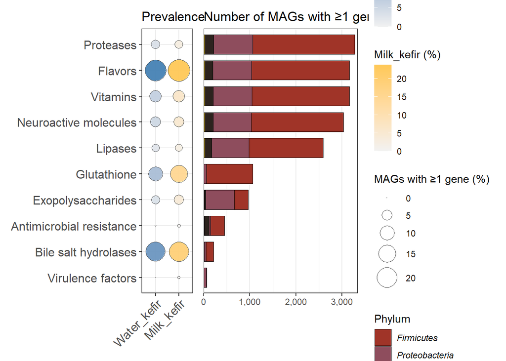

```r
phyla_cols_kefir <- c(
  "Firmicutes"      = "#A03428",
  "Proteobacteria"  = "#8E4D5D",
  "Actinobacteria"  = "#2C231E",
  "Bacteroidota"    = "#FFD92F"
)

functional_overview_df <- read.table(
  "../../data/functional_overview_df.csv",
  header       = TRUE,
  sep          = ",",
  check.names  = FALSE,
  dec          = ".",
  comment.char = "",
  quote        = "\"",
  na.strings   = "NA"
)

# Restore the same y-axis order for both panels.
category_levels <- functional_overview_df %>%
  distinct(category, category_order) %>%
  arrange(category_order) %>%
  pull(category)

# Left panel: prevalence by kefir subtype.
bubble_df <- functional_overview_df %>%
  filter(panel == "bubble") %>%
  arrange(group_order, category_order) %>%
  transmute(
    Subtype  = factor(group, levels = unique(group)),
    category = factor(category, levels = category_levels),
    pct      = pct
  )

# Right panel: MAG counts by phylum.
bars_df <- functional_overview_df %>%
  filter(panel == "bar") %>%
  arrange(group_order, category_order) %>%
  transmute(
    category = factor(category, levels = category_levels),
    phylum   = factor(group, levels = unique(group)),
    n_hits   = n_hits
  )

# The original plot uses these totals to outline each stacked bar.
bar_totals <- bars_df %>%
  group_by(category) %>%
  summarise(total = sum(n_hits), .groups = "drop")

# Recover the exact named palettes used in the analysis.
subtype_cols <- functional_overview_df %>%
  filter(panel == "bubble") %>%
  distinct(group, colour) %>%
  tibble::deframe()

phylum_colors <- functional_overview_df %>%
  filter(panel == "bar") %>%
  distinct(group, colour) %>%
  tibble::deframe()

bubble_title <- "Prevalence"
legend_title <- "MAGs with ≥1 gene (%)"

# ---- 10. Colour palette for subtypes ----
subtype_cols <- c(
  "Water_kefir" = "steelblue",
  "Milk_kefir"  = "#FFC857"
)

# ---- 11. Build bubble plot with per-group fill gradients ----
mx_val  <- max(bubble_df$pct, na.rm = TRUE)
brks_sz <- pretty(c(0, mx_val), n = 4)

p_bubble_func <- ggplot()

for (lvl in levels(bubble_df$Subtype)) {
  dat <- filter(bubble_df, Subtype == lvl)

  if (nrow(dat) == 0) next

  mx_lev <- max(dat$pct, na.rm = TRUE)
  if (mx_lev == 0) mx_lev <- 1

  p_bubble_func <- p_bubble_func +
    geom_point(
      data = dat,
      aes(x = Subtype, y = category, size = pct, fill = pct),
      shape = 21,
      colour = "grey25",
      alpha = 0.95
    ) +
    scale_fill_gradientn(
      colours = c("#F2F2F2", subtype_cols[[lvl]]),
      limits  = c(0, mx_lev),
      name    = paste0(lvl, " (%)")
    ) +
    ggnewscale::new_scale_fill()
}

p_bubble_func <- p_bubble_func +
  scale_size_area(max_size = 10, breaks = brks_sz, name = legend_title) +
  guides(fill = "none") +
  labs(x = NULL, y = NULL, title = bubble_title) +
  theme_bw(base_size = 11) +
  theme(
    axis.text.y = element_text(size = 12),
    axis.text.x = element_text(angle = 45, hjust = 1, size = 12),
    legend.box = "vertical",
    legend.spacing.y = unit(2, "mm")
  )

# ---- 12. Bar plot data (phylum composition) ----
bars_df <- bars_df %>%
  tidyr::complete(category, phylum, fill = list(n_hits = 0)) %>%
  mutate(
    phylum = forcats::fct_reorder(phylum, n_hits, .fun = sum, .desc = TRUE)
  )

bar_totals <- bars_df %>%
  group_by(category) %>%
  summarise(total = sum(n_hits), .groups = "drop")

# ---- 13. Phylum colour palette (extend your existing one) ----
phyla_cols_kefir_extended <- c(
  phyla_cols_kefir,
  "Acidobacteriota" = "#E6AB02",
  "Armatimonadota"  = "#8E6F5D",
  "Deinococcota"    = "#D0AA81",
  "Others"          = "#BDBDBD"
)

all_phyla <- levels(bars_df$phylum)

phylum_colors <- setNames(
  ifelse(
    all_phyla %in% names(phyla_cols_kefir_extended),
    phyla_cols_kefir_extended[all_phyla],
    phyla_cols_kefir_extended["Others"]
  ),
  all_phyla
)

functional_overview_df <- dplyr::bind_rows(
  bubble_df %>%
    dplyr::transmute(
      panel          = "bubble",
      category_order = as.integer(category),
      category       = as.character(category),
      group_order    = as.integer(Subtype),
      group          = as.character(Subtype),
      colour         = unname(subtype_cols[group]),
      pct            = pct
    ),

  bars_df %>%
    dplyr::transmute(
      panel          = "bar",
      category_order = as.integer(category),
      category       = as.character(category),
      group_order    = as.integer(phylum),
      group          = as.character(phylum),
      colour         = unname(phylum_colors[group]),
      n_hits         = n_hits
    )
)

# ---- 14. Bar plot ----
p_bars_phylum_func <- ggplot() +
  geom_col(
    data = bars_df,
    aes(y = category, x = n_hits, fill = phylum),
    width = 0.75,
    colour = "black",
    linewidth = 0.25
  ) +
  geom_col(
    data = bar_totals,
    aes(y = category, x = total),
    width = 0.75,
    fill = NA,
    colour = "black",
    linewidth = 0.25
  ) +
  scale_x_continuous(
    labels = scales::label_number(big.mark = ","),
    expand = expansion(mult = c(0, 0.02))
  ) +
  scale_fill_manual(values = phylum_colors, name = "Phylum") +
  labs(x = NULL, y = NULL, title = "Number of MAGs with ≥1 gene") +
  theme_bw(base_size = 11) +
  theme(
    axis.text.y = element_blank(),
    axis.ticks.y = element_blank(),
    panel.grid.major.y = element_blank(),
    legend.position = "right",
    legend.text = element_text(face = "italic")
  ) +
  guides(fill = guide_legend(ncol = 1, byrow = TRUE))

# ---- 15. Combine and save ----
p_combo_phylum_func <- (p_bubble_func + p_bars_phylum_func) +
  patchwork::plot_layout(widths = c(25, 75), guides = "collect")

stopifnot(identical(levels(bubble_df$category), levels(bars_df$category)))

print(p_combo_phylum_func)
```

## Fig. 8B

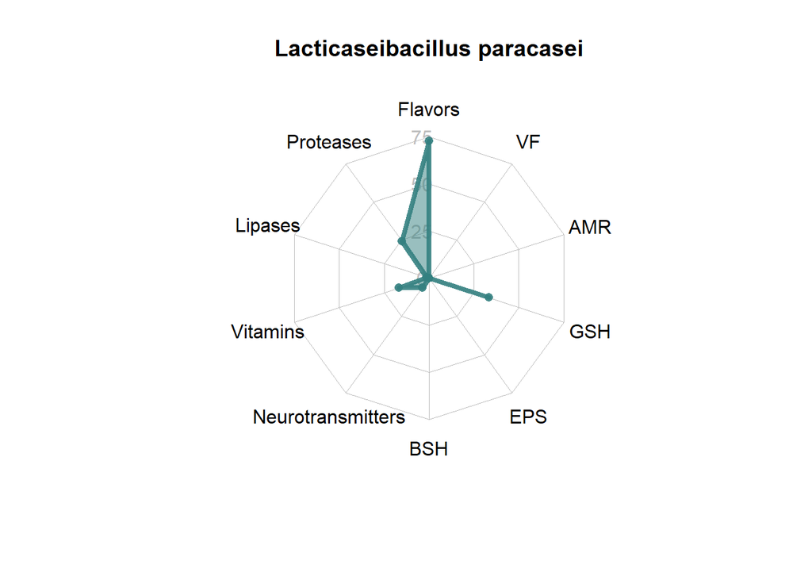

```r
species_function_radar  <- read.table(
  "../../data/all_species_functional_relative_gene_richness.tsv",
  header       = TRUE,
  sep          = "\t",
  check.names  = FALSE,
  dec          = ".",
  comment.char = "",
  quote        = "\"",
  na.strings   = "NA"
)

plot_species_radar <- function(species_to_plot) {

  # Extract the functional profile of the selected species
  data <- species_function_radar %>%
    filter(Species == species_to_plot)

  # Skip species not present in the functional table
  if (nrow(data) == 0) {
    warning(paste("Species not found:", species_to_plot))
    return(NULL)
  }

  # Remove taxonomy column: radarchart() requires numeric variables only
  data <- data %>%
    select(-Species) %>%
    as.data.frame()

  # Warn if the fixed radar maximum of 75 is exceeded
  if (any(data > 75, na.rm = TRUE)) {
    warning(
      paste0(
        species_to_plot,
        ": at least one value exceeds 75; maximum = ",
        round(max(data, na.rm = TRUE), 2)
      )
    )
  }

  # Add fixed MAX and MIN rows.
  # This guarantees the same 0–75 scale for every species.
  data <- rbind(
    MAX = rep(75, ncol(data)),
    MIN = rep(0, ncol(data)),
    data
  )

  # Radar chart
  radarchart(
    data,
    axistype = 1,

    # 0 → 25 → 50 → 75
    seg = 3,
    centerzero = TRUE,

    # Polygon
    pcol  = rgb(0.2, 0.5, 0.5, 0.9),
    pfcol = rgb(0.2, 0.5, 0.5, 0.5),
    plwd  = 4,

    # Grid
    cglcol = "grey",
    cglty = 1,
    cglwd = 0.8,

    # Radial axis
    axislabcol = "grey",
    caxislabels = seq(0, 75, 25),

    # Functional-class labels
    vlcex = 1,

    # Species title
    title = gsub("_", " ", species_to_plot)
  )

}

plot_species_radar("Lacticaseibacillus_paracasei")
```

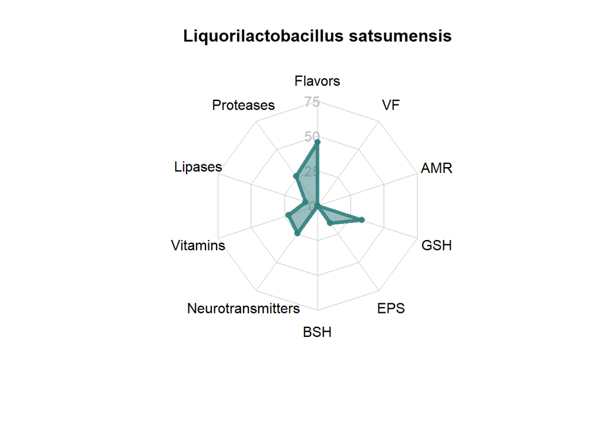

```r
plot_species_radar("Liquorilactobacillus_satsumensis")
```

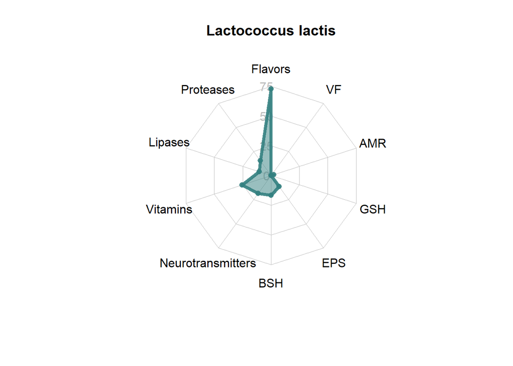

```r
plot_species_radar("Lactococcus_lactis")
```

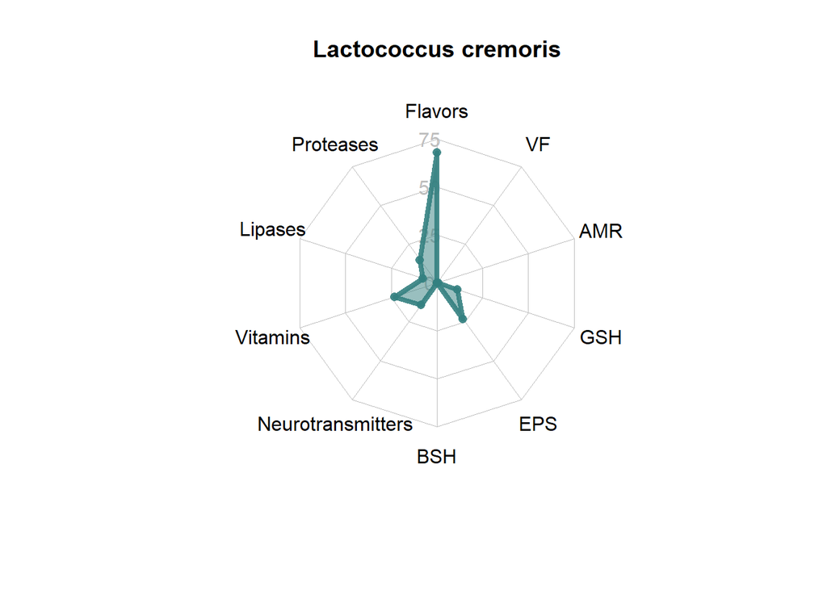

```r
plot_species_radar("Lactococcus_cremoris")
```

## Fig. 9A-C

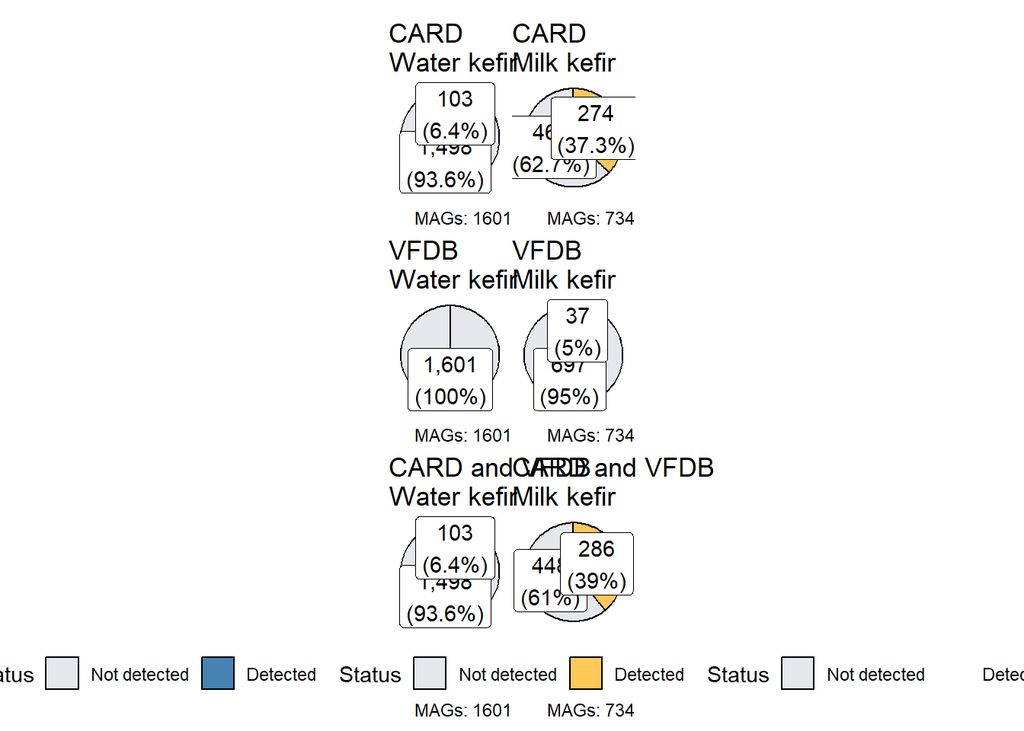

```r
meta_pa_card_vf_sum  <- read.table(
  "../../data/meta_pa_card_vf_sum.csv",
  header       = TRUE,
  sep          = ",",
  check.names  = FALSE,
  dec          = ".",
  comment.char = "",
  quote        = "\"",
  na.strings   = "NA"
)

# Colours
subtype_cols <- c(
  "Water_kefir" = "steelblue",
  "Milk_kefir"  = "#FFC857"
)

# Prepare the three categories
plot_data <- meta_pa_card_vf_sum %>%
  filter(Subtype %in% names(subtype_cols)) %>%
  pivot_longer(
    cols = c(Sum_of_CARD, Sum_of_VFDB, Sum_of_CARD_VFDB),
    names_to = "Category",
    values_to = "Gene_count"
  ) %>%
  mutate(
    Category = factor(
      Category,
      levels = c("Sum_of_CARD", "Sum_of_VFDB", "Sum_of_CARD_VFDB"),
      labels = c("CARD", "VFDB", "CARD and VFDB")
    ),
    Status = factor(
      Gene_count > 0,
      levels = c(FALSE, TRUE),
      labels = c("Not detected", "Detected")
    )
  )

# One row per category, one column per observed subtype
subtypes <- names(subtype_cols)[
  names(subtype_cols) %in% plot_data$Subtype
]

pieplots <- list()

for (category in levels(plot_data$Category)) {
  for (subtype in subtypes) {

    dat <- plot_data %>%
      filter(Category == category, Subtype == subtype) %>%
      droplevels()

    pieplots[[length(pieplots) + 1]] <- ggpiestats(
      data = dat,
      x = Status,
      results.subtitle = FALSE,
      proportion.test = FALSE,
      bf.message = FALSE,
      label = "both",
      digits.perc = 1,
      title = paste(category, gsub("_", " ", subtype), sep = "\n"),
      caption = paste("MAGs:", nrow(dat)),
      legend.title = NULL,
      ggtheme = theme_void()
    ) +
      scale_fill_manual(
        values = c(
          "Not detected" = "#E5E7EB",
          "Detected" = unname(subtype_cols[subtype])
        ),
        limits = c("Not detected", "Detected"),
        drop = FALSE
      ) +
      theme(legend.position = "bottom")
  }
}

# Combine and display
p_card_vf_pies <- wrap_plots(
  pieplots,
  ncol = length(subtypes),
  guides = "collect"
) &
  theme(legend.position = "bottom")

print(p_card_vf_pies)
```

## Supplementary Fig. 1A (left)

```r
permdisp_df_jaccard <- read.table("../../data/permdisp_df_jaccard.csv",
                                  header = TRUE,
                                  sep = ",",
                                  check.names = FALSE,
                                  comment.char = "",
                                  quote = "",
                                  na = ""
                                  ) %>% as.data.frame()

# Use the existing kefir palette for Subtype.
subtype_palette <- kefir_palettes[["Subtype"]]
permdisp_df_jaccard$color_id <- subtype_palette[permdisp_df_jaccard$Subtype]
permdisp_df_jaccard$color_id[is.na(permdisp_df_jaccard$color_id)] <- "grey50"
my_col_individual <- setNames(
  permdisp_df_jaccard$color_id,
  permdisp_df_jaccard$Subtype
)

# ---- 3. Pairwise Wilcoxon tests with FDR correction ----
permdisp_wilcox_df_jaccard <- permdisp_df_jaccard %>%
  filter(
    !is.na(Subtype),
    !is.na(DistanceToMedian)
  ) %>%
  group_by(Subtype) %>%
  filter(n() >= 2) %>%
  ungroup() %>%
  droplevels()

if (n_distinct(permdisp_wilcox_df_jaccard$Subtype) >= 2) {

  pairwise_results_jaccard <- permdisp_wilcox_df_jaccard %>%
    rstatix::wilcox_test(DistanceToMedian ~ Subtype) %>%
    rstatix::adjust_pvalue(method = "fdr") %>%
    rstatix::add_significance(
      p.col     = "p.adj",
      cutpoints = c(0, 0.0001, 0.001, 0.01, 0.05, 1),
      symbols   = c("****", "***", "**", "*", "ns")
    ) %>%
    filter(p.adj.signif != "ns")

} else {

  pairwise_results_jaccard <- tibble()
  cat(
    "Pairwise Wilcoxon tests skipped: fewer than 2 subtypes ",
    "with at least 2 observations.\n",
    sep = ""
  )
}

max_y_jaccard <- max(permdisp_df_jaccard$DistanceToMedian, na.rm = TRUE)

if (nrow(pairwise_results_jaccard) > 0) {

  pairwise_results_jaccard <- pairwise_results_jaccard %>%
    mutate(
      y.position = max_y_jaccard + row_number() * max_y_jaccard * 0.06
    )

  cat(
    "Significant pairwise Wilcoxon comparisons retained: ",
    nrow(pairwise_results_jaccard), "\n",
    sep = ""
  )

} else {

  cat("No significant pairwise Wilcoxon comparisons to annotate.\n")
}
```

```
Significant pairwise Wilcoxon comparisons retained: 1
```

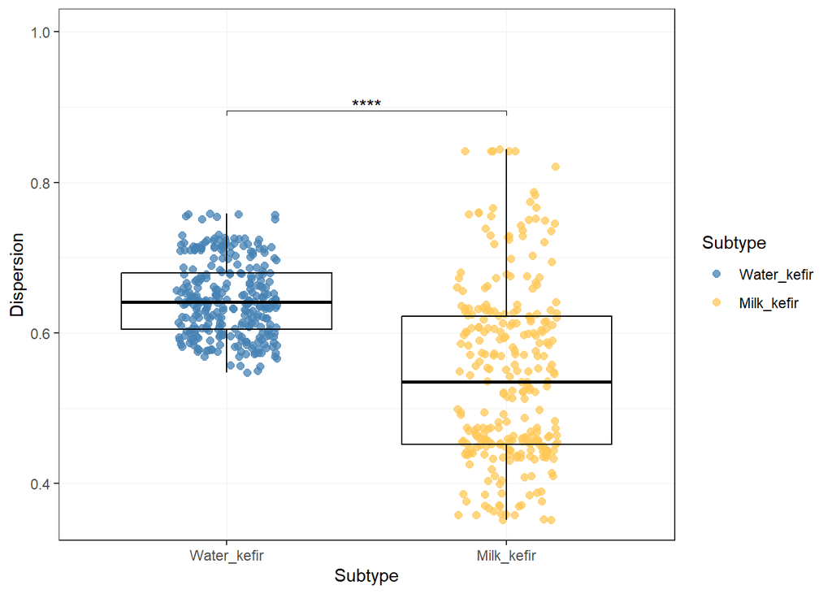

```r
# ---- 4. PERMDISP plot (corrected colour mapping) ----
# Make Subtype a factor with the order from the palette
permdisp_df_jaccard$Subtype <- factor(permdisp_df_jaccard$Subtype,
                                   levels = names(subtype_palette))

fig_permdisp_subtype_jaccard <- ggplot(permdisp_df_jaccard,
                                    aes(x = Subtype,
                                        y = DistanceToMedian,
                                        colour = Subtype)) +   # <-- map to Subtype, not color_id
  geom_jitter(width = 0.18,
              size  = 2,
              alpha = 0.75) +
  geom_boxplot(aes(group = Subtype),
               colour        = 'black',
               fill          = NA,
               outlier.shape = NA,
               linewidth     = 0.5) +
  scale_color_manual(values = subtype_palette,   # <-- direct use of the palette
                     name   = 'Subtype') +
  scale_y_continuous(expand = expansion(mult = c(0.05, 0.25))) +
  labs(
    title = NULL,
    x     = 'Subtype',
    y     = 'Dispersion'
  ) +
  theme_bw(base_size = 11) +
  theme(
    plot.title    = element_text(face = 'bold', size = 12, hjust = 0.5),
    plot.subtitle = element_text(size = 10, hjust = 0.5),
    axis.text.x   = element_text(angle = 0, hjust = 0.5),
    panel.grid    = element_line(colour = 'grey94', linewidth = 0.3),
    legend.position = 'right'
  )

# Add significance brackets (unchanged)
if (nrow(pairwise_results_jaccard) > 0) {
  fig_permdisp_subtype_jaccard <- fig_permdisp_subtype_jaccard +
    stat_pvalue_manual(
      pairwise_results_jaccard,
      label      = 'p.adj.signif',
      xmin       = 'group1',
      xmax       = 'group2',
      y.position = 'y.position',
      tip.length = 0.01,
      size       = 4,
      colour     = 'black',
      hide.ns    = TRUE
    )
}

fig_permdisp_subtype_jaccard
```

## Supplementary Fig. 1A (right)

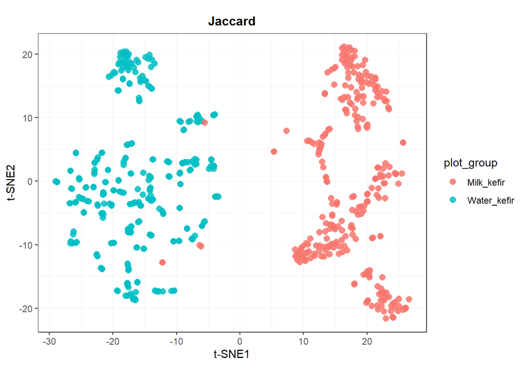

```r
tsne_df_jaccard <- read.table("../../data/tsne_df_jaccard.csv",
                      header = TRUE,
                      sep = ",",
                      check.names = FALSE,
                      comment.char = "",
                      quote = "",
                      na = ""
) %>% as.data.frame()

wa_subset_tsne <- read.table("../../data/wa_subset_tsne_jaccard.csv",
                             header = TRUE,
                             sep = ",",
                             check.names = FALSE,
                             comment.char = "",
                             quote = "",
                             na = ""
) %>% as.data.frame()

fig_tsne <- ggplot(tsne_df_jaccard,
                   aes(x = tSNE1, y = tSNE2, colour = plot_group)) +
  geom_point(size = 2.5, alpha = 0.85) +
  #scale_colour_manual(
  #values = plot_palette_tsne,
  #name   = plot_colour,
  #drop   = FALSE
  #) +
  coord_fixed() +
  labs(
    title    = paste0("Jaccard"),
    #subtitle = bquote(R^2 == .(r2_val) * ", " ~ italic(p) == .(pval_fmt)),
    x        = "t-SNE1",
    y        = "t-SNE2"
  ) +
  theme_bw(base_size = 11) +
  theme(
    plot.title    = element_text(face = "bold", size = 12, hjust = 0.5),
    plot.subtitle = element_text(hjust = 0.5, size = 10),
    panel.grid    = element_line(colour = "grey94", linewidth = 0.3),
    legend.position = "right"
  )

fig_tsne
```

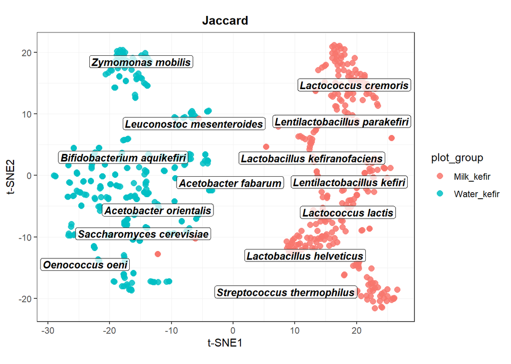

```r
fig_tsne_species <- fig_tsne +
  geom_label_repel(
    data = wa_subset_tsne,
    aes(x = tSNE1, y = tSNE2, label = species_label_plot),
    inherit.aes   = FALSE,
    colour        = "black",
    fill          = grDevices::adjustcolor("white", alpha.f = 0.75),
    fontface      = "bold.italic",
    size          = 3.5,
    label.size    = 0.25,
    label.r       = unit(0.15, "lines"),
    label.padding = unit(0.15, "lines"),
    box.padding   = 0.25,
    point.padding = 0.1,
    segment.color = "grey98"
  )

fig_tsne_species
```

## Supplementary Fig. 1B (left)

```r
permdisp_df_aitchison <- read.table("../../data/permdisp_df_aitchison.csv",
                               header = TRUE,
                               sep = ",",
                               check.names = FALSE,
                               comment.char = "",
                               quote = "",
                               na = ""
) %>% as.data.frame()

# Use the existing kefir palette for Subtype.
subtype_palette <- kefir_palettes[["Subtype"]]
permdisp_df_aitchison$color_id <- subtype_palette[permdisp_df_aitchison$Subtype]
permdisp_df_aitchison$color_id[is.na(permdisp_df_aitchison$color_id)] <- "grey50"
my_col_individual <- setNames(
  permdisp_df_aitchison$color_id,
  permdisp_df_aitchison$Subtype
)

# ---- 3. Pairwise Wilcoxon tests with FDR correction ----
permdisp_wilcox_df_aitchison <- permdisp_df_aitchison %>%
  filter(
    !is.na(Subtype),
    !is.na(DistanceToMedian)
  ) %>%
  group_by(Subtype) %>%
  filter(n() >= 2) %>%
  ungroup() %>%
  droplevels()

if (n_distinct(permdisp_wilcox_df_aitchison$Subtype) >= 2) {

  pairwise_results_aitchison <- permdisp_wilcox_df_aitchison %>%
    rstatix::wilcox_test(DistanceToMedian ~ Subtype) %>%
    rstatix::adjust_pvalue(method = "fdr") %>%
    rstatix::add_significance(
      p.col     = "p.adj",
      cutpoints = c(0, 0.0001, 0.001, 0.01, 0.05, 1),
      symbols   = c("****", "***", "**", "*", "ns")
    ) %>%
    filter(p.adj.signif != "ns")

} else {

  pairwise_results_aitchison <- tibble()
  cat(
    "Pairwise Wilcoxon tests skipped: fewer than 2 subtypes ",
    "with at least 2 observations.\n",
    sep = ""
  )
}

max_y_aitchison <- max(permdisp_df_aitchison$DistanceToMedian, na.rm = TRUE)

if (nrow(pairwise_results_aitchison) > 0) {

  pairwise_results_aitchison <- pairwise_results_aitchison %>%
    mutate(
      y.position = max_y_aitchison + row_number() * max_y_aitchison * 0.06
    )

  cat(
    "Significant pairwise Wilcoxon comparisons retained: ",
    nrow(pairwise_results_aitchison), "\n",
    sep = ""
  )

} else {

  cat("No significant pairwise Wilcoxon comparisons to annotate.\n")
}
```

```
Significant pairwise Wilcoxon comparisons retained: 1
```

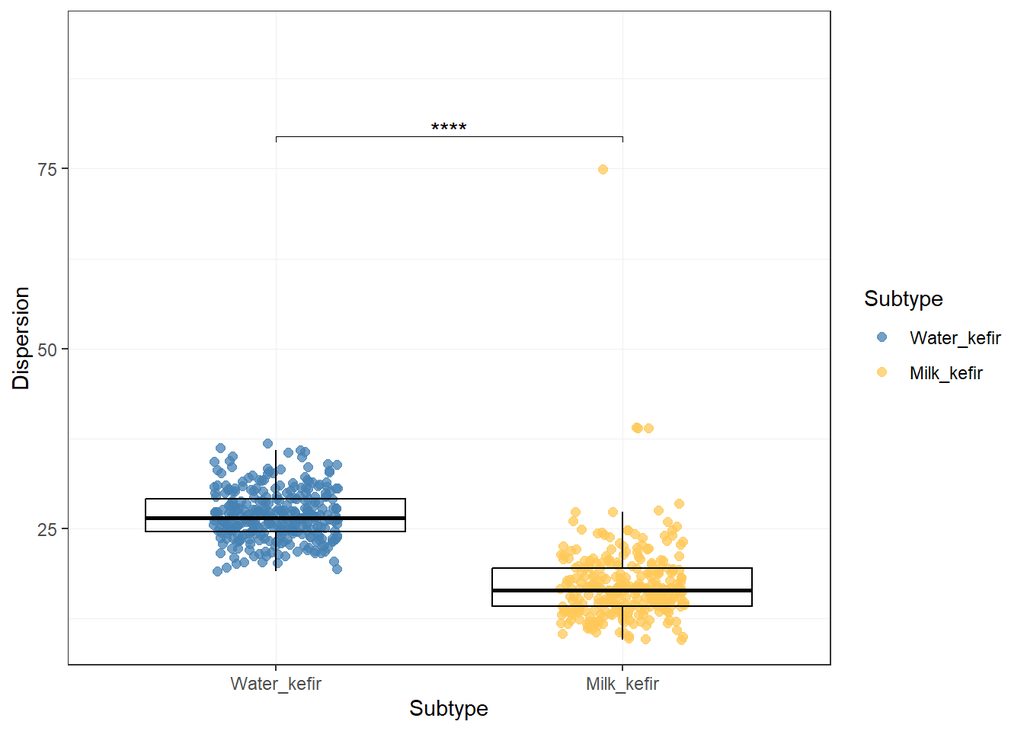

```r
# ---- 4. PERMDISP plot (corrected colour mapping) ----
# Make Subtype a factor with the order from the palette
permdisp_df_aitchison$Subtype <- factor(permdisp_df_aitchison$Subtype,
                                   levels = names(subtype_palette))

fig_permdisp_subtype_aitchison <- ggplot(permdisp_df_aitchison,
                                    aes(x = Subtype,
                                        y = DistanceToMedian,
                                        colour = Subtype)) +   # <-- map to Subtype, not color_id
  geom_jitter(width = 0.18,
              size  = 2,
              alpha = 0.75) +
  geom_boxplot(aes(group = Subtype),
               colour        = 'black',
               fill          = NA,
               outlier.shape = NA,
               linewidth     = 0.5) +
  scale_color_manual(values = subtype_palette,   # <-- direct use of the palette
                     name   = 'Subtype') +
  scale_y_continuous(expand = expansion(mult = c(0.05, 0.25))) +
  labs(
    title = NULL,
    x     = 'Subtype',
    y     = 'Dispersion'
  ) +
  theme_bw(base_size = 11) +
  theme(
    plot.title    = element_text(face = 'bold', size = 12, hjust = 0.5),
    plot.subtitle = element_text(size = 10, hjust = 0.5),
    axis.text.x   = element_text(angle = 0, hjust = 0.5),
    panel.grid    = element_line(colour = 'grey94', linewidth = 0.3),
    legend.position = 'right'
  )

# Add significance brackets (unchanged)
if (nrow(pairwise_results_aitchison) > 0) {
  fig_permdisp_subtype_aitchison <- fig_permdisp_subtype_aitchison +
    stat_pvalue_manual(
      pairwise_results_aitchison,
      label      = 'p.adj.signif',
      xmin       = 'group1',
      xmax       = 'group2',
      y.position = 'y.position',
      tip.length = 0.01,
      size       = 4,
      colour     = 'black',
      hide.ns    = TRUE
    )
}

fig_permdisp_subtype_aitchison
```